# Project 4: Multi-factor Model

## Instructions

Each problem consists of a function to implement and instructions on how to implement the function. The parts of the function that need to be implemented are marked with a `# TODO` comment. After implementing the function, run the cell to test it against the unit tests we've provided. For each problem, we provide one or more unit tests from our `project_tests` package. These unit tests won't tell you if your answer is correct, but will warn you of any major errors. Your code will be checked for the correct solution when you submit it to Udacity.

## Packages

When you implement the functions, you'll only need to you use the packages you've used in the classroom, like [Pandas](https://pandas.pydata.org/) and [Numpy](http://www.numpy.org/). These packages will be imported for you. We recommend you don't add any import statements, otherwise the grader might not be able to run your code.

The other packages that we're importing are `project_helper` and `project_tests`. These are custom packages built to help you solve the problems. The `project_helper` module contains utility functions and graph functions. The `project_tests` contains the unit tests for all the problems.

### Install Packages

```python
import sys
!{sys.executable} -m pip install --upgrade pip
!{sys.executable} -m pip install --upgrade wheel setuptools build
!{sys.executable} -m pip install -r requirements.txt
```

[output not shown]

[output cut: 30 more lines]

[output not shown]

### Load Packages

```python
import cvxpy as cvx
import numpy as np
import pandas as pd
import time
import project_tests
import project_helper

import matplotlib.pyplot as plt
%matplotlib inline
plt.style.use('ggplot')
plt.rcParams['figure.figsize'] = (14, 8)
```

## Data Bundle

We'll be using Zipline to handle our data. We've created a end of day data bundle for this project. Run the cell below to register this data bundle in zipline.

```python
import os
import project_helper
from zipline.data import bundles

os.environ['ZIPLINE_ROOT'] = os.path.join(os.getcwd(), '..', '..', 'data', 'project_4_eod')

ingest_func = bundles.csvdir.csvdir_equities(['daily'], project_helper.EOD_BUNDLE_NAME)
bundles.register(project_helper.EOD_BUNDLE_NAME, ingest_func)

print('Data Registered')
```

```
Data Registered
```

## Build Pipeline Engine

We'll be using Zipline's pipeline package to access our data for this project. To use it, we must build a pipeline engine. Run the cell below to build the engine.

```python
from zipline.pipeline import Pipeline
from zipline.pipeline.factors import AverageDollarVolume
from zipline.utils.calendars import get_calendar


universe = AverageDollarVolume(window_length=120).top(500)
trading_calendar = get_calendar('NYSE')
bundle_data = bundles.load(project_helper.EOD_BUNDLE_NAME)
engine = project_helper.build_pipeline_engine(bundle_data, trading_calendar)
```

### View Data

With the pipeline engine built, let's get the stocks at the end of the period in the universe we're using. We'll use these tickers to generate the returns data for the our risk model.

```python
universe_end_date = pd.Timestamp('2016-01-05', tz='UTC')

universe_tickers = engine\
    .run_pipeline(
        Pipeline(screen=universe),
        universe_end_date,
        universe_end_date)\
    .index.get_level_values(1)\
    .values.tolist()

universe_tickers
```

```
[Equity(0 [A]),
 Equity(1 [AAL]),
 Equity(2 [AAP]),
 Equity(3 [AAPL]),
 Equity(4 [ABBV]),
 Equity(5 [ABC]),
 Equity(6 [ABT]),
 Equity(7 [ACN]),
 Equity(8 [ADBE]),
 Equity(9 [ADI]),
 Equity(10 [ADM]),
 Equity(11 [ADP]),
 Equity(12 [ADS]),
 Equity(13 [ADSK]),
 Equity(14 [AEE]),
 Equity(15 [AEP]),
 Equity(16 [AES]),
 Equity(17 [AET]),
 Equity(18 [AFL]),
 Equity(19 [AGN]),
 Equity(20 [AIG]),
 Equity(21 [AIV]),
 Equity(22 [AIZ]),
 Equity(23 [AJG]),
 Equity(24 [AKAM]),
 Equity(25 [ALB]),
 Equity(26 [ALGN]),
 Equity(27 [ALK]),
 Equity(28 [ALL]),
 Equity(29 [ALLE]),
 Equity(30 [ALXN]),
 Equity(31 [AMAT]),
 Equity(32 [AMD]),
 Equity(33 [AME]),
 Equity(34 [AMG]),
 Equity(35 [AMGN]),
 Equity(36 [AMP]),
 Equity(37 [AMT]),
 Equity(38 [AMZN]),
 Equity(39 [ANDV]),
```

[output cut: 435 more lines]

```
 Equity(476 [WY]),
 Equity(477 [WYN]),
 Equity(478 [WYNN]),
 Equity(479 [XEC]),
 Equity(480 [XEL]),
 Equity(481 [XL]),
 Equity(482 [XLNX]),
 Equity(483 [XOM]),
 Equity(484 [XRAY]),
 Equity(485 [XRX]),
 Equity(486 [XYL]),
 Equity(487 [YUM]),
 Equity(488 [ZBH]),
 Equity(489 [ZION]),
 Equity(490 [ZTS])]
```

## Get Returns

Not that we have our pipeline built, let's access the returns data. We'll start by building a data portal.

```python
from zipline.data.data_portal import DataPortal


data_portal = DataPortal(
    bundle_data.asset_finder,
    trading_calendar=trading_calendar,
    first_trading_day=bundle_data.equity_daily_bar_reader.first_trading_day,
    equity_minute_reader=None,
    equity_daily_reader=bundle_data.equity_daily_bar_reader,
    adjustment_reader=bundle_data.adjustment_reader)
```

To make the code easier to read, we've built the helper function `get_pricing` to get the pricing from the data portal.

```python
def get_pricing(data_portal, trading_calendar, assets, start_date, end_date, field='close'):
    end_dt = pd.Timestamp(end_date.strftime('%Y-%m-%d'), tz='UTC', offset='C')
    start_dt = pd.Timestamp(start_date.strftime('%Y-%m-%d'), tz='UTC', offset='C')

    end_loc = trading_calendar.closes.index.get_loc(end_dt)
    start_loc = trading_calendar.closes.index.get_loc(start_dt)

    return data_portal.get_history_window(
        assets=assets,
        end_dt=end_dt,
        bar_count=end_loc - start_loc,
        frequency='1d',
        field=field,
        data_frequency='daily')
```

### View Data

Let's get returns data for our risk model using the `get_pricing` function. For this model, we'll be looking back to 5 years of data.

```python
five_year_returns = \
    get_pricing(
        data_portal,
        trading_calendar,
        universe_tickers,
        universe_end_date - pd.DateOffset(years=5),
        universe_end_date)\
    .pct_change()[1:].fillna(0)

five_year_returns
```

|  | Equity(0 [A]) | Equity(1 [AAL]) | Equity(2 [AAP]) | Equity(3 [AAPL]) | Equity(4 [ABBV]) | Equity(5 [ABC]) | Equity(6 [ABT]) | Equity(7 [ACN]) | Equity(8 [ADBE]) | Equity(9 [ADI]) | ... | Equity(481 [XL]) | Equity(482 [XLNX]) | Equity(483 [XOM]) | Equity(484 [XRAY]) | Equity(485 [XRX]) | Equity(486 [XYL]) | Equity(487 [YUM]) | Equity(488 [ZBH]) | Equity(489 [ZION]) | Equity(490 [ZTS]) |
| --- | --- | --- | --- | --- | --- | --- | --- | --- | --- | --- | --- | --- | --- | --- | --- | --- | --- | --- | --- | --- | --- |
| 2011-01-07 00:00:00+00:00 | 0.00843652 | 0.01423027 | 0.02670202 | 0.00714639 | 0.00000000 | 0.00199434 | 0.00416541 | 0.00164769 | -0.00712736 | -0.00581846 | ... | -0.00183775 | -0.00561865 | 0.00546091 | -0.00404361 | -0.01395259 | 0.00000000 | 0.01245693 | -0.00018145 | -0.01045802 | 0.00000000 |
| 2011-01-10 00:00:00+00:00 | -0.00417428 | 0.00619534 | 0.00743543 | 0.01885158 | 0.00000000 | -0.00571429 | -0.00889600 | -0.00885384 | 0.02871411 | 0.00292626 | ... | 0.00094687 | 0.00781438 | -0.00608100 | 0.01046585 | 0.00973303 | 0.00000000 | 0.00143979 | 0.00778351 | -0.01794496 | 0.00000000 |
| 2011-01-11 00:00:00+00:00 | -0.00188630 | -0.04364361 | -0.00592730 | -0.00236744 | 0.00000000 | 0.00978303 | -0.00206747 | 0.01371668 | 0.00060680 | 0.00875316 | ... | 0.00131385 | 0.01017933 | 0.00744242 | 0.00735141 | 0.00611644 | 0.00000000 | -0.00646974 | 0.03567570 | 0.00746728 | 0.00000000 |
| 2011-01-12 00:00:00+00:00 | 0.01725375 | -0.00823708 | 0.01338721 | 0.00813289 | 0.00000000 | -0.00597922 | -0.00101061 | 0.02296913 | 0.01795027 | 0.00025710 | ... | 0.00498609 | 0.01566621 | 0.01176334 | 0.02718194 | 0.00438630 | 0.00000000 | 0.00263106 | 0.01474083 | -0.01190269 | 0.00000000 |
| 2011-01-13 00:00:00+00:00 | -0.00455851 | 0.00095465 | 0.00303109 | 0.00365656 | 0.00000000 | 0.01492537 | -0.00445119 | -0.00040011 | -0.00571905 | -0.00501221 | ... | 0.03049927 | -0.00321668 | 0.00169383 | 0.00054651 | -0.01823475 | 0.00000000 | -0.00508430 | -0.00466453 | -0.00917796 | 0.00000000 |
| 2011-01-14 00:00:00+00:00 | 0.00343886 | -0.00915594 | 0.00302193 | 0.00810620 | 0.00000000 | 0.00139452 | -0.01011076 | 0.00259000 | 0.01228280 | 0.01982692 | ... | 0.02660653 | 0.02589425 | 0.01474258 | -0.00028748 | 0.02649446 | 0.00000000 | -0.02166101 | 0.00594885 | 0.03317747 | 0.00000000 |
| 2011-01-18 00:00:00+00:00 | 0.03425353 | -0.06208490 | -0.00428562 | -0.02247419 | 0.00000000 | 0.02088872 | 0.00662116 | 0.00699843 | 0.01154188 | 0.03264518 | ... | 0.00167843 | 0.00250133 | 0.01116324 | 0.01158879 | 0.00604402 | 0.00000000 | 0.02945339 | 0.00699753 | -0.00853448 | 0.00000000 |
| 2011-01-19 00:00:00+00:00 | -0.01022379 | -0.00892857 | 0.00875376 | -0.00531448 | 0.00000000 | -0.01714410 | 0.00275342 | -0.00296182 | -0.00789936 | -0.02057462 | ... | -0.01483416 | -0.02358990 | -0.00596800 | -0.01989880 | -0.01284667 | 0.00000000 | 0.00081838 | -0.00409759 | -0.01843318 | 0.00000000 |
| 2011-01-20 00:00:00+00:00 | -0.00849568 | 0.02195299 | -0.00473189 | -0.01818900 | 0.00000000 | 0.00479450 | 0.01332249 | 0.01871257 | -0.01238573 | -0.00281761 | ... | -0.02451226 | 0.00774353 | -0.00626137 | -0.00084112 | -0.03379775 | 0.00000000 | -0.01318157 | -0.00161165 | -0.00797236 | 0.00000000 |
| 2011-01-21 00:00:00+00:00 | 0.00787281 | -0.04103759 | 0.00554409 | -0.01791080 | 0.00000000 | 0.01064197 | -0.00085307 | -0.00195169 | -0.00656913 | -0.00411277 | ... | 0.00000000 | 0.00061472 | 0.01582494 | -0.00304798 | -0.00087153 | 0.00000000 | -0.00759032 | 0.00932467 | 0.02402000 | 0.00000000 |
| 2011-01-24 00:00:00+00:00 | 0.01464622 | 0.02747253 | -0.00110591 | 0.03283704 | 0.00000000 | 0.00524943 | 0.00522324 | 0.00842018 | 0.02284340 | 0.01497431 | ... | 0.01235897 | 0.01601137 | -0.00494300 | 0.00165968 | 0.00804885 | 0.00000000 | 0.00060118 | -0.01650140 | -0.02302058 | 0.00000000 |
| 2011-01-25 00:00:00+00:00 | -0.00673624 | 0.00298231 | 0.00914590 | 0.01170955 | 0.00000000 | -0.00936254 | -0.00434674 | 0.00485935 | -0.01381134 | -0.01450491 | ... | 0.00217821 | 0.00627338 | 0.00115375 | 0.00113369 | 0.01514317 | 0.00000000 | -0.00620848 | 0.01714176 | -0.00883613 | 0.00000000 |
| 2011-01-26 00:00:00+00:00 | -0.03073582 | 0.06613350 | 0.00359340 | 0.00719342 | 0.00000000 | 0.01222707 | -0.02524087 | 0.01219180 | -0.00119190 | 0.00283652 | ... | 0.00262839 | 0.00593383 | 0.01245258 | 0.00055168 | -0.07629122 | 0.00000000 | -0.00480301 | -0.01952376 | -0.01062584 | 0.00000000 |
| 2011-01-27 00:00:00+00:00 | 0.00772081 | 0.02317753 | -0.00155262 | -0.00187707 | 0.00000000 | 0.01183286 | -0.00792793 | 0.00017944 | 0.00984487 | 0.00747981 | ... | 0.01426699 | 0.02116856 | 0.00275077 | 0.01639630 | 0.02466443 | 0.00000000 | -0.00374620 | 0.06875384 | 0.02016019 | 0.00000000 |
| 2011-01-28 00:00:00+00:00 | -0.01884631 | -0.08055268 | -0.00093620 | -0.02070958 | 0.00000000 | -0.02226215 | -0.01919983 | -0.01603463 | -0.04017725 | -0.02245999 | ... | -0.02564740 | -0.02010822 | -0.01113056 | -0.02187072 | -0.02222859 | 0.00000000 | -0.02500085 | -0.00847214 | -0.01387340 | 0.00000000 |
| 2011-01-31 00:00:00+00:00 | 0.00360809 | -0.02361480 | -0.00235062 | 0.00957845 | 0.00000000 | -0.00389347 | -0.00724829 | -0.00098003 | 0.01723607 | 0.01381753 | ... | 0.00484620 | 0.00029849 | 0.02139566 | -0.00756028 | 0.00661503 | 0.00000000 | 0.00774817 | 0.00990224 | 0.00637836 | 0.00000000 |
| 2011-02-01 00:00:00+00:00 | 0.01165376 | -0.00104701 | -0.00921769 | 0.01681783 | 0.00000000 | 0.01197624 | 0.00154551 | 0.01749823 | 0.01391831 | 0.02162417 | ... | 0.01568687 | 0.03200298 | 0.04003746 | 0.02479485 | 0.02449777 | 0.00000000 | 0.01410150 | 0.01774607 | 0.03097047 | 0.00000000 |
| 2011-02-02 00:00:00+00:00 | 0.01011176 | -0.03930406 | -0.02747650 | -0.00205320 | 0.00000000 | -0.02119705 | 0.01106795 | 0.00363229 | -0.00238735 | 0.00227994 | ... | -0.01284550 | -0.00451785 | -0.00595828 | -0.01038976 | -0.00182689 | 0.00000000 | 0.00656172 | 0.00516054 | -0.00370596 | 0.00000000 |
| 2011-02-03 00:00:00+00:00 | -0.00028893 | 0.00730962 | 0.01412639 | -0.00256035 | 0.00000000 | -0.00366196 | 0.00589443 | 0.00417765 | 0.00299133 | -0.01334112 | ... | 0.01043038 | -0.00816904 | 0.00034726 | 0.00855568 | 0.00459592 | 0.00000000 | 0.03141255 | -0.00033292 | -0.00039386 | 0.00000000 |
| 2011-02-04 00:00:00+00:00 | 0.00562724 | -0.03649951 | 0.02401434 | 0.00891547 | 0.00000000 | 0.03304712 | 0.00261602 | -0.00436050 | -0.00507009 | 0.01965916 | ... | 0.00947084 | 0.02470898 | -0.00191681 | 0.00304817 | -0.00550607 | 0.00000000 | 0.00140817 | 0.00247147 | 0.01611067 | 0.00000000 |
| 2011-02-07 00:00:00+00:00 | 0.00770895 | 0.05204586 | 0.00811404 | 0.01553804 | 0.00000000 | -0.00217765 | -0.00934092 | 0.00227918 | 0.00599520 | -0.00351381 | ... | 0.00680069 | -0.00507270 | 0.00780293 | 0.00685187 | 0.00276828 | 0.00000000 | 0.00202754 | -0.01087565 | 0.02761741 | 0.00000000 |
| 2011-02-08 00:00:00+00:00 | 0.01085425 | 0.01645475 | 0.00620226 | 0.00943966 | 0.00000000 | 0.00218240 | -0.00173831 | -0.00055735 | 0.00029797 | -0.00600987 | ... | 0.00384577 | 0.00179527 | -0.00607698 | 0.00518223 | -0.00276064 | 0.00000000 | 0.00385105 | -0.00049496 | 0.00477967 | 0.00000000 |
| 2011-02-09 00:00:00+00:00 | 0.00466351 | 0.00000000 | 0.01695500 | 0.00833204 | 0.00000000 | 0.00300577 | -0.00153026 | 0.00113763 | -0.01668156 | 0.00478144 | ... | -0.01183694 | -0.00179205 | -0.00517814 | -0.01844088 | 0.00370461 | 0.00000000 | -0.00182061 | -0.00985108 | -0.00475694 | 0.00000000 |
| 2011-02-10 00:00:00+00:00 | 0.00041298 | -0.00304846 | -0.01136679 | -0.01010922 | 0.00000000 | 0.00110085 | -0.00110982 | 0.00550344 | 0.01696456 | 0.00451308 | ... | -0.00894677 | 0.00391368 | 0.00787593 | 0.00551211 | -0.00462381 | 0.00000000 | 0.00485295 | 0.01144950 | -0.02649784 | 0.00000000 |
| 2011-02-11 00:00:00+00:00 | -0.00714982 | 0.02836356 | 0.00076442 | 0.00650490 | 0.00000000 | -0.00137455 | 0.00153431 | -0.01114607 | 0.00297885 | 0.01500657 | ... | 0.00170520 | 0.01076538 | -0.00456215 | 0.00714655 | 0.01202070 | 0.00000000 | 0.00061584 | 0.00965987 | 0.01425557 | 0.00000000 |
| 2011-02-14 00:00:00+00:00 | 0.00166312 | -0.01579001 | -0.02327358 | 0.00652903 | 0.00000000 | 0.00575047 | 0.00924459 | 0.00020168 | 0.00564301 | 0.00987654 | ... | -0.01161568 | 0.00031846 | 0.02522953 | -0.00544299 | 0.00547592 | 0.00000000 | 0.01065725 | 0.00248369 | -0.01002123 | 0.00000000 |
| 2011-02-15 00:00:00+00:00 | -0.01190476 | 0.01104282 | -0.00392614 | 0.00201613 | 0.00000000 | -0.00732946 | 0.01674954 | -0.00802079 | 0.00236267 | 0.00023854 | ... | -0.00607872 | -0.00180403 | -0.02285301 | 0.00409742 | 0.00360404 | 0.00000000 | 0.00852564 | -0.00181453 | -0.00446084 | 0.00000000 |
| 2011-02-16 00:00:00+00:00 | 0.01512325 | 0.00195775 | 0.01385974 | 0.00896684 | 0.00000000 | -0.00355392 | -0.01050193 | 0.02732858 | 0.02209782 | -0.00390509 | ... | 0.00917384 | 0.00386265 | 0.00868160 | 0.00028536 | 0.02709281 | 0.00000000 | 0.00889849 | 0.01055741 | 0.00120638 | 0.00000000 |
| 2011-02-17 00:00:00+00:00 | -0.00331066 | -0.01779103 | -0.02484354 | -0.01330906 | 0.00000000 | 0.02914771 | 0.00130066 | 0.01178385 | 0.00835976 | 0.00855903 | ... | 0.01565577 | 0.00031771 | 0.00227521 | -0.00191139 | 0.00000000 | 0.00000000 | 0.00390600 | 0.01532474 | -0.00322747 | 0.00000000 |
| 2011-02-18 00:00:00+00:00 | 0.01107771 | -0.02010261 | -0.00669325 | -0.02159490 | 0.00000000 | 0.00961998 | 0.01210641 | -0.00795272 | 0.01172098 | -0.00169134 | ... | 0.05340361 | 0.00144687 | 0.00739258 | 0.01314812 | -0.00438988 | 0.00000000 | -0.00411045 | 0.02378154 | -0.01795968 | 0.00000000 |
| ... | ... | ... | ... | ... | ... | ... | ... | ... | ... | ... | ... | ... | ... | ... | ... | ... | ... | ... | ... | ... | ... |
| 2015-11-20 00:00:00+00:00 | 0.00107212 | -0.00237346 | 0.00276686 | 0.00438086 | 0.00925624 | -0.00090483 | 0.00611281 | 0.00643014 | 0.00054490 | -0.00584294 | ... | 0.00813121 | 0.00041182 | -0.00635194 | 0.00279330 | 0.00289932 | -0.00449783 | 0.01505987 | -0.00317570 | 0.00000000 | 0.00894971 |
| 2015-11-23 00:00:00+00:00 | -0.00709429 | 0.00237910 | -0.00122838 | -0.01298872 | 0.00064612 | -0.00372792 | -0.01238148 | -0.00120585 | 0.00163381 | -0.04410655 | ... | -0.00469574 | -0.00695468 | 0.00613134 | 0.00734514 | 0.02769219 | 0.00132239 | -0.00096628 | -0.00858098 | -0.00199203 | -0.00760006 |
| 2015-11-24 00:00:00+00:00 | 0.00208486 | -0.02530879 | 0.00350426 | 0.00959410 | -0.00032285 | -0.00233603 | 0.00020972 | -0.00453713 | 0.00043497 | 0.06374097 | ... | -0.00077707 | 0.01295953 | 0.01993523 | -0.00956300 | -0.01299182 | -0.00187091 | -0.00425172 | -0.00904325 | 0.00264987 | -0.00065084 |
| 2015-11-25 00:00:00+00:00 | -0.00820649 | 0.00193813 | 0.00680544 | -0.00715141 | -0.01374361 | 0.00436515 | -0.00086201 | -0.00233759 | -0.00250000 | -0.00281048 | ... | -0.00888765 | -0.00445842 | -0.00768963 | -0.00279190 | -0.00191255 | 0.00482386 | 0.00289380 | -0.00617420 | -0.00030891 | 0.00086836 |
| 2015-11-27 00:00:00+00:00 | -0.00325586 | 0.00920070 | 0.00328491 | -0.00186283 | -0.00480271 | 0.00061184 | 0.00020986 | 0.00336265 | 0.00435872 | 0.00331472 | ... | 0.00473588 | 0.00447839 | -0.00025651 | 0.00263307 | 0.00379485 | -0.00213974 | 0.00510503 | -0.00286889 | 0.00501270 | 0.00234253 |
| 2015-11-30 00:00:00+00:00 | -0.01020870 | -0.01032093 | -0.01279784 | 0.00415919 | -0.03083813 | -0.00354229 | -0.01100361 | -0.00222774 | -0.00770316 | 0.01952228 | ... | 0.00421152 | 0.00934761 | 0.00529351 | -0.00736321 | -0.00752358 | -0.00692784 | -0.00618325 | 0.00010131 | -0.00433862 | -0.00807150 |
| 2015-12-01 00:00:00+00:00 | 0.01574786 | 0.04849282 | -0.00239635 | -0.00811576 | 0.01495718 | 0.00871792 | 0.01202178 | 0.00848039 | 0.01191778 | -0.00097042 | ... | 0.01519233 | 0.01107484 | 0.00282087 | 0.02160044 | 0.01327550 | 0.00858179 | 0.02716952 | 0.01692683 | 0.01502831 | 0.00663191 |
| 2015-12-02 00:00:00+00:00 | -0.00528420 | 0.01293012 | -0.02716607 | -0.00902983 | -0.02202152 | -0.00653437 | -0.00528731 | -0.00499107 | -0.00572663 | -0.00699034 | ... | -0.00385752 | -0.02469292 | -0.02857143 | 0.00757240 | -0.02996241 | -0.01833503 | 0.00631281 | -0.00447256 | -0.01544806 | -0.01360986 |
| 2015-12-03 00:00:00+00:00 | -0.00952117 | -0.01255465 | -0.01994438 | -0.00929219 | -0.02772394 | -0.00141471 | -0.02365007 | -0.01542891 | -0.02292980 | -0.02782630 | ... | -0.00829420 | -0.01081970 | -0.01432669 | 0.00273291 | -0.00095925 | -0.00567594 | -0.02427203 | -0.02836674 | -0.01572478 | -0.02524442 |
| 2015-12-04 00:00:00+00:00 | 0.02019919 | 0.03930296 | 0.00677909 | 0.03324578 | 0.01889890 | 0.01195750 | 0.02604566 | 0.02992398 | 0.02969636 | 0.00271314 | ... | 0.02221053 | 0.01032552 | 0.00573563 | 0.00749501 | 0.01159888 | 0.02477363 | 0.04115927 | 0.01197660 | 0.02445235 | 0.02788171 |
| 2015-12-07 00:00:00+00:00 | -0.00033987 | 0.01801987 | -0.02957813 | -0.00629799 | -0.01592051 | 0.00089849 | 0.00572671 | -0.00146283 | -0.03218838 | -0.01198796 | ... | 0.00000000 | -0.00879092 | -0.02612215 | -0.00190007 | -0.02957591 | -0.01964712 | 0.00353962 | -0.00138396 | -0.04208519 | -0.01184133 |
| 2015-12-08 00:00:00+00:00 | -0.02330712 | -0.02687583 | -0.00886608 | -0.00042489 | 0.00711446 | 0.00490595 | -0.00020917 | -0.00027950 | 0.02366071 | -0.00821590 | ... | -0.00460567 | -0.00391018 | -0.02825109 | -0.01206744 | -0.00492958 | -0.01707392 | -0.01073476 | -0.00627720 | -0.03181317 | 0.00066573 |
| 2015-12-09 00:00:00+00:00 | -0.00516964 | -0.02021340 | 0.02222267 | -0.02207699 | -0.01130272 | 0.00198396 | -0.01294807 | -0.01487559 | -0.02354993 | -0.02360837 | ... | -0.01309164 | -0.00993443 | 0.01338977 | -0.02106570 | -0.00986868 | -0.00056952 | -0.02367896 | 0.00220474 | -0.00748954 | -0.01590047 |
| 2015-12-10 00:00:00+00:00 | 0.01503860 | 0.01009224 | -0.00946596 | 0.00476320 | -0.00446315 | 0.01271990 | 0.00777184 | 0.00289674 | -0.00669942 | 0.00882138 | ... | -0.00675676 | 0.00188278 | 0.00079770 | -0.00031695 | 0.01497042 | 0.01213779 | -0.00825643 | -0.00029673 | 0.01475919 | 0.01969533 |
| 2015-12-11 00:00:00+00:00 | -0.01222670 | -0.04535632 | -0.01917906 | -0.02573993 | -0.03118548 | 0.00127956 | -0.02096235 | -0.02137978 | 0.02765288 | -0.00384301 | ... | -0.01493822 | -0.01271252 | -0.01783980 | -0.01775464 | -0.01279343 | -0.01306196 | -0.02583602 | -0.01011228 | -0.02978165 | -0.00585635 |
| 2015-12-14 00:00:00+00:00 | -0.01119741 | -0.00761835 | -0.00832534 | -0.00618871 | 0.02589759 | 0.00440628 | 0.01014465 | 0.01007090 | 0.02012689 | -0.00193824 | ... | 0.00721594 | -0.00094052 | 0.02273800 | -0.00183474 | -0.01791305 | 0.01158048 | 0.00490982 | 0.00535594 | -0.01499098 | 0.01658331 |
| 2015-12-15 00:00:00+00:00 | 0.02468348 | 0.01976847 | 0.05799045 | -0.01768577 | 0.01713257 | -0.00819372 | 0.01741535 | 0.00338602 | 0.00814926 | -0.00474296 | ... | 0.01539193 | 0.01351594 | 0.04471023 | 0.00435700 | 0.01622211 | 0.00163542 | 0.01341047 | 0.01578682 | 0.03562574 | 0.00815639 |
| 2015-12-16 00:00:00+00:00 | 0.01078027 | 0.01419020 | 0.02977102 | 0.00768495 | 0.02199833 | -0.00098521 | 0.01007990 | 0.02210700 | 0.01637949 | 0.01733616 | ... | 0.00471295 | 0.00053077 | -0.00352152 | 0.00850674 | 0.02493746 | 0.02071897 | 0.01280939 | 0.00860603 | 0.01075467 | 0.00253774 |
| 2015-12-17 00:00:00+00:00 | -0.01721238 | -0.01712199 | -0.04819014 | -0.02119576 | -0.02169610 | 0.00738610 | -0.01715337 | -0.05335502 | -0.01423190 | -0.02450989 | ... | -0.00156361 | -0.01814726 | -0.01503666 | -0.00314212 | -0.00778738 | -0.02669682 | -0.01822419 | -0.01196571 | -0.01596035 | -0.00763722 |
| 2015-12-18 00:00:00+00:00 | -0.04108447 | -0.03225884 | -0.02286262 | -0.02706364 | -0.01134153 | -0.00449706 | -0.03446098 | -0.01288309 | -0.03067941 | -0.01693954 | ... | -0.01901256 | -0.01231427 | -0.00872355 | -0.01045055 | -0.00394377 | -0.01700150 | -0.00499057 | -0.01738362 | -0.03784484 | -0.00279062 |
| 2015-12-21 00:00:00+00:00 | 0.00945523 | 0.03186317 | 0.00053085 | 0.01225425 | 0.00824462 | 0.00991570 | 0.00777786 | 0.01040390 | 0.00339503 | 0.01196200 | ... | 0.00635765 | 0.01677569 | -0.00025549 | 0.00703494 | 0.01477910 | 0.00835952 | 0.02171387 | 0.01284185 | 0.00227072 | 0.01589418 |
| 2015-12-22 00:00:00+00:00 | 0.01050225 | 0.01167033 | -0.01175973 | -0.00092672 | 0.02474629 | 0.00261687 | 0.00997788 | 0.00747281 | 0.02401222 | 0.00332573 | ... | 0.03167093 | 0.00273487 | 0.00505438 | 0.01004736 | 0.03886271 | 0.00997684 | -0.00544780 | 0.01496575 | 0.01455341 | 0.00802720 |
| 2015-12-23 00:00:00+00:00 | 0.01180348 | 0.00921901 | 0.00832501 | 0.01286896 | 0.01717833 | 0.00756710 | 0.01395006 | 0.00636498 | 0.00937966 | 0.00829624 | ... | 0.00919881 | 0.00950124 | 0.03270236 | 0.00758616 | 0.01119292 | 0.01723748 | 0.01534943 | 0.01021896 | 0.01877295 | 0.00544406 |
| 2015-12-24 00:00:00+00:00 | -0.00368236 | 0.01202196 | 0.00046505 | -0.00534053 | -0.00204082 | 0.00009036 | 0.00000000 | -0.00181999 | -0.00422386 | 0.00567317 | ... | 0.00962284 | -0.00062007 | -0.01072430 | -0.00212741 | 0.00555290 | -0.00161385 | -0.00162043 | 0.00136401 | 0.00397518 | 0.00312135 |
| 2015-12-28 00:00:00+00:00 | 0.00704030 | -0.01325882 | 0.00952567 | -0.01120361 | 0.00495300 | 0.00230910 | -0.00154955 | -0.00144052 | -0.00106045 | -0.00616419 | ... | 0.00050303 | -0.00106364 | -0.00743906 | 0.00493013 | -0.02113809 | -0.00348374 | -0.00217727 | -0.00641306 | -0.00503256 | -0.00478388 |
| 2015-12-29 00:00:00+00:00 | 0.01944279 | 0.00625637 | 0.01095726 | 0.01797599 | 0.01191076 | 0.00556913 | 0.01754180 | 0.01191401 | 0.01199575 | 0.01522413 | ... | 0.01381318 | 0.00796362 | 0.00533553 | 0.01143615 | 0.01128297 | 0.00430697 | 0.00541538 | 0.00723499 | 0.00617376 | 0.00899694 |
| 2015-12-30 00:00:00+00:00 | -0.00638405 | -0.01608535 | -0.00525423 | -0.01305616 | 0.00590373 | 0.00239063 | -0.01201673 | 0.00512422 | -0.00052449 | -0.01325558 | ... | -0.01461683 | -0.00706442 | -0.01326109 | -0.00807866 | 0.00184720 | -0.00618212 | -0.00578080 | -0.00292090 | -0.01223479 | -0.00145450 |
| 2015-12-31 00:00:00+00:00 | -0.01243206 | -0.01053186 | -0.00587919 | -0.01919944 | -0.00937219 | -0.01248112 | -0.00795266 | -0.01284442 | -0.01406381 | -0.02174525 | ... | -0.01605213 | -0.01817456 | -0.00205030 | -0.00911914 | -0.00837082 | -0.01003138 | -0.01029925 | 0.00117577 | -0.00621188 | -0.00705088 |
| 2016-01-04 00:00:00+00:00 | -0.02828157 | -0.03398810 | 0.01149418 | 0.00085542 | -0.02751240 | -0.01774070 | -0.04406668 | -0.02555086 | -0.02097083 | -0.01591868 | ... | -0.02476714 | -0.02492212 | -0.00627612 | -0.03271090 | -0.03105128 | -0.01151995 | -0.01148918 | -0.00760365 | -0.02161389 | -0.01356408 |
| 2016-01-05 00:00:00+00:00 | 0.00405845 | -0.00954098 | -0.00683002 | -0.02505441 | -0.00416936 | 0.01462920 | -0.00024665 | 0.00520704 | 0.00402305 | -0.00734750 | ... | 0.00209794 | 0.01486318 | 0.00851070 | 0.02039022 | -0.00195732 | -0.00028634 | -0.00249493 | 0.02081954 | -0.01085325 | 0.01564723 |

1256 rows × 490 columns

# Statistical Risk Model

It's time to build the risk model. You'll be creating a statistical risk model using PCA. So, the first thing is building the PCA model.

## Fit PCA

Implement `fit_pca` to fit a PCA model to the returns data

```python
from sklearn.decomposition import PCA


def fit_pca(returns, num_factor_exposures, svd_solver):
    """
    Fit PCA model with returns.

    Parameters
    ----------
    returns : DataFrame
        Returns for each ticker and date
    num_factor_exposures : int
        Number of factors for PCA
    svd_solver: str
        The solver to use for the PCA model

    Returns
    -------
    pca : PCA
        Model fit to returns
    """
    #TODO: Implement function
    model = PCA(n_components=num_factor_exposures, svd_solver=svd_solver)
    model.fit(returns)

    return model


project_tests.test_fit_pca(fit_pca)
```

```
Tests Passed
```

### View Data

Let's see what the model looks like. First, we'll look at the PCA components.

```python
num_factor_exposures = 20
pca = fit_pca(five_year_returns, num_factor_exposures, 'full')

pca.components_
```

```
array([[-0.04316847, -0.05874471, -0.03433256, ..., -0.03843904,
        -0.06092493, -0.01367163],
       [ 0.01955111,  0.19637679,  0.03451503, ...,  0.01749339,
        -0.01044197,  0.01892192],
       [-0.00993375,  0.07868756,  0.01133839, ..., -0.0157519 ,
         0.01261759,  0.01867875],
       ...,
       [-0.01174265,  0.01398085,  0.05143999, ...,  0.04125323,
         0.0035229 ,  0.03682367],
       [ 0.00526925, -0.04680674,  0.05716915, ...,  0.00671842,
        -0.02193923,  0.00833979],
       [-0.00535269, -0.01599057,  0.08414961, ..., -0.01540844,
         0.02188794,  0.01500221]])
```

Let's also look at the PCA's percent of variance explained by each factor

```
<Container object of 20 artists>
```

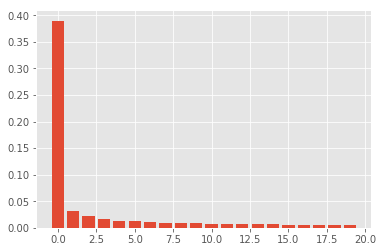

```python
plt.bar(np.arange(num_factor_exposures), pca.explained_variance_ratio_)
```

You will see that the first factor dominates. The precise definition of each factor in a latent model is unknown, however we can guess at the likely interpretation.

## Factor Betas

Implement `factor_betas` to get the factor betas from the PCA model.

```python
def factor_betas(pca, factor_beta_indices, factor_beta_columns):
    """
    Get the factor betas from the PCA model.

    Parameters
    ----------
    pca : PCA
        Model fit to returns
    factor_beta_indices : 1 dimensional Ndarray
        Factor beta indices
    factor_beta_columns : 1 dimensional Ndarray
        Factor beta columns

    Returns
    -------
    factor_betas : DataFrame
        Factor betas
    """
    assert len(factor_beta_indices.shape) == 1
    assert len(factor_beta_columns.shape) == 1

    #TODO: Implement function
    factor_betas = pd.DataFrame(data=pca.components_.T, index=factor_beta_indices, columns=factor_beta_columns)

    return factor_betas


project_tests.test_factor_betas(factor_betas)
```

```
Tests Passed
```

### View Data

Let's view the factor betas from this model.

```python
risk_model = {}
risk_model['factor_betas'] = factor_betas(pca, five_year_returns.columns.values, np.arange(num_factor_exposures))

risk_model['factor_betas']
```

|  | 0 | 1 | 2 | 3 | 4 | 5 | 6 | 7 | 8 | 9 | 10 | 11 | 12 | 13 | 14 | 15 | 16 | 17 | 18 | 19 |
| --- | --- | --- | --- | --- | --- | --- | --- | --- | --- | --- | --- | --- | --- | --- | --- | --- | --- | --- | --- | --- |
| Equity(0 [A]) | -0.04316847 | 0.01955111 | -0.00993375 | 0.01054038 | -0.01819821 | 0.01074517 | 0.00112915 | 0.03973914 | -0.01380519 | 0.01273651 | -0.02384028 | -0.00141663 | 0.02099338 | 0.03460997 | -0.03048936 | 0.03360635 | -0.01142920 | -0.01174265 | 0.00526925 | -0.00535269 |
| Equity(1 [AAL]) | -0.05874471 | 0.19637679 | 0.07868756 | 0.08209582 | 0.34847826 | -0.13808246 | 0.07129285 | 0.10524788 | -0.04588957 | -0.08547793 | 0.00328328 | 0.10534284 | 0.06721603 | -0.04405955 | -0.02231617 | 0.01726309 | -0.03310836 | 0.01398085 | -0.04680674 | -0.01599057 |
| Equity(2 [AAP]) | -0.03433256 | 0.03451503 | 0.01133839 | -0.02543666 | -0.00817211 | -0.01318319 | -0.06095238 | 0.00654915 | -0.03265404 | -0.01351522 | 0.02896685 | 0.03836520 | -0.04960451 | -0.00524576 | -0.02196994 | 0.02976718 | -0.01163585 | 0.05143999 | 0.05716915 | 0.08414961 |
| Equity(3 [AAPL]) | -0.03409988 | -0.00139319 | 0.03946700 | -0.01721303 | -0.03046983 | -0.01757067 | 0.02325117 | 0.01142987 | -0.02656849 | -0.00771904 | 0.02686350 | 0.00731877 | 0.00481832 | 0.01288623 | 0.05256513 | -0.07344470 | -0.03179158 | 0.09079374 | -0.01118851 | 0.04291373 |
| Equity(4 [ABBV]) | -0.01803099 | 0.02568151 | 0.00435183 | -0.07078179 | 0.01319937 | 0.05427710 | -0.01567842 | 0.04046172 | -0.01245487 | -0.03515086 | -0.05132433 | -0.04041614 | -0.05120320 | -0.01858166 | -0.01126857 | -0.04200714 | 0.01588559 | 0.04598554 | 0.01599288 | 0.06587978 |
| Equity(5 [ABC]) | -0.02890016 | 0.03259161 | -0.00742074 | -0.03355183 | -0.01152149 | 0.02648421 | 0.01084965 | -0.00570393 | 0.01354800 | -0.02967931 | -0.03161765 | 0.01715152 | -0.00304998 | 0.02635564 | 0.00787900 | 0.00833106 | -0.01834622 | -0.01391370 | 0.01062042 | -0.02739565 |
| Equity(6 [ABT]) | -0.02905740 | 0.02977821 | -0.02970871 | -0.03574263 | -0.01157351 | 0.06020073 | -0.02004042 | 0.04098522 | -0.01803987 | -0.00620785 | -0.03157790 | -0.02308041 | -0.01436789 | -0.00054254 | -0.01932887 | 0.01428819 | -0.03938064 | 0.01071208 | 0.01712006 | 0.00210689 |
| Equity(7 [ACN]) | -0.04337745 | 0.00256907 | 0.00413229 | -0.00349265 | -0.05430743 | 0.00537434 | 0.00277996 | 0.03043220 | -0.01880168 | -0.00178336 | -0.03540357 | -0.01093170 | 0.02611241 | -0.01233115 | 0.00322097 | 0.01770011 | -0.00285123 | -0.01235874 | -0.01400935 | -0.03855653 |
| Equity(8 [ADBE]) | -0.04730285 | 0.02661175 | 0.03057072 | -0.02114690 | -0.04838794 | -0.00708698 | 0.00743385 | 0.00747095 | 0.01487098 | -0.00153422 | -0.01238383 | -0.00667442 | 0.03500718 | -0.04336579 | 0.01060255 | -0.00637875 | 0.02127339 | -0.03638845 | 0.00126811 | -0.04844555 |
| Equity(9 [ADI]) | -0.04712287 | -0.00381150 | 0.05600847 | -0.01553775 | -0.06946243 | -0.00560418 | 0.10070366 | 0.06307694 | 0.00160769 | 0.01912993 | 0.01101680 | 0.00348733 | -0.05465749 | -0.04223802 | -0.00014275 | -0.04843166 | 0.00374282 | 0.04583322 | 0.01483456 | 0.00768623 |
| Equity(10 [ADM]) | -0.04375945 | -0.01130045 | -0.03457005 | 0.00400541 | -0.00645333 | 0.01746845 | -0.00146122 | 0.04177642 | -0.00478644 | -0.01859623 | 0.00422432 | -0.00952513 | -0.01336835 | 0.01753074 | 0.00993158 | 0.02405739 | -0.02009143 | -0.00246866 | 0.00264238 | -0.00851815 |
| Equity(11 [ADP]) | -0.03648136 | 0.02528125 | -0.01114832 | -0.00940984 | -0.03357614 | 0.02887659 | -0.00509280 | 0.04466799 | -0.00676480 | 0.00335015 | -0.00493401 | 0.00194010 | -0.01057350 | -0.00616905 | -0.00351046 | -0.00218630 | -0.00363522 | 0.00584571 | 0.00578868 | -0.02465380 |
| Equity(12 [ADS]) | -0.04136654 | 0.01659887 | 0.01716323 | -0.02418717 | -0.00389740 | 0.00098181 | -0.02299563 | 0.01316338 | -0.02790599 | 0.00654660 | 0.00628604 | -0.00342924 | 0.01596979 | -0.02290249 | 0.01812681 | 0.00269984 | -0.01166061 | -0.02387829 | -0.01844799 | 0.02639087 |
| Equity(13 [ADSK]) | -0.06028785 | 0.01995266 | 0.05164356 | 0.00105689 | -0.06889175 | -0.04893180 | 0.04706144 | -0.02746946 | 0.00290438 | 0.00534281 | -0.01150281 | -0.00105789 | 0.04046916 | -0.03266419 | 0.02070996 | 0.02100687 | 0.05625388 | -0.06442852 | -0.03374250 | -0.02718282 |
| Equity(14 [AEE]) | -0.02646901 | 0.02222316 | -0.10714999 | -0.03824488 | -0.00157895 | -0.02310383 | 0.02412315 | 0.04419314 | 0.00041473 | -0.02597657 | 0.02325386 | -0.05456489 | 0.00729924 | -0.00884432 | 0.02876494 | 0.02575176 | 0.03531642 | -0.00801202 | -0.03297087 | -0.03074790 |
| Equity(15 [AEP]) | -0.02263370 | 0.01880106 | -0.10030310 | -0.04210462 | 0.00205558 | -0.03150526 | 0.02496444 | 0.05473617 | 0.00166554 | -0.02261936 | 0.01766823 | -0.04791054 | -0.01334963 | -0.00584932 | 0.03513664 | 0.02664964 | 0.03949487 | 0.00571290 | -0.01621889 | -0.01421124 |
| Equity(16 [AES]) | -0.04557539 | -0.01859287 | -0.06960047 | -0.02023102 | 0.01303429 | -0.01748403 | 0.02894033 | 0.03053573 | -0.01228381 | -0.02623395 | 0.00383933 | -0.05881947 | -0.01427757 | 0.01071751 | 0.04800697 | 0.00823278 | 0.00968720 | -0.02229136 | -0.05731240 | -0.01503171 |
| Equity(17 [AET]) | -0.04072498 | 0.02731997 | -0.00507231 | -0.02802199 | -0.00180323 | 0.06383735 | 0.00044765 | -0.03716524 | 0.00999656 | -0.09646860 | -0.04571407 | 0.04559328 | -0.08527159 | 0.06484179 | -0.07164819 | 0.00852602 | 0.01958565 | 0.00069996 | 0.00650320 | -0.05091908 |
| Equity(18 [AFL]) | -0.05336864 | 0.00134653 | -0.02782496 | 0.06688998 | -0.01355109 | 0.04111821 | -0.00401011 | -0.01388700 | 0.01362724 | 0.00343990 | -0.00993833 | -0.00945988 | 0.01378441 | -0.00676370 | 0.00047075 | 0.00042919 | 0.00010718 | 0.00397769 | 0.01677661 | -0.03209361 |
| Equity(19 [AGN]) | -0.03534102 | 0.04465091 | 0.02264084 | -0.09556088 | 0.02867567 | 0.06515425 | -0.02264216 | -0.01928860 | -0.02379115 | -0.02578767 | -0.02640179 | -0.00734949 | -0.01375720 | 0.01729325 | 0.00910558 | 0.01765223 | -0.02289392 | 0.02583835 | -0.02092126 | 0.01964563 |
| Equity(20 [AIG]) | -0.05982324 | 0.00588515 | -0.01162873 | 0.06668318 | 0.01385338 | 0.04010201 | -0.01874280 | -0.02394864 | 0.01457678 | 0.02061950 | -0.00588748 | -0.01886738 | -0.00536267 | -0.02808023 | 0.03227634 | -0.01100650 | -0.00994737 | -0.04884961 | -0.01447059 | -0.00092722 |
| Equity(21 [AIV]) | -0.04111735 | 0.03100207 | -0.10211708 | -0.00919327 | 0.01055402 | -0.04739093 | 0.05244727 | -0.09495931 | 0.04963087 | 0.00394508 | 0.02486556 | 0.02540802 | 0.02094801 | -0.04206507 | -0.02048654 | -0.03732772 | -0.01518008 | 0.02499635 | 0.04526409 | 0.06168561 |
| Equity(22 [AIZ]) | -0.04150874 | 0.01695771 | -0.03297298 | 0.04770347 | -0.00003273 | 0.04220872 | -0.00295921 | 0.01717020 | 0.02192818 | -0.01979049 | 0.00845285 | -0.00209358 | -0.02121338 | -0.01017076 | 0.02874684 | 0.01121282 | 0.00889890 | -0.01278457 | 0.00035505 | 0.00788631 |
| Equity(23 [AJG]) | -0.03351812 | 0.01723113 | -0.02538602 | 0.01303842 | -0.00670008 | 0.02117990 | -0.01015869 | 0.00117300 | 0.00768045 | 0.00434263 | -0.00824876 | 0.01520847 | -0.00142810 | -0.00802982 | -0.00533986 | -0.00140466 | -0.00386327 | -0.01466289 | -0.00523534 | 0.01165450 |
| Equity(24 [AKAM]) | -0.05587884 | 0.00798596 | 0.06670064 | -0.00705542 | -0.05149731 | -0.04837770 | 0.02745032 | -0.00620225 | 0.02668695 | -0.01154353 | 0.00107161 | -0.06366032 | -0.07429360 | 0.00240076 | 0.12416841 | 0.13836518 | 0.00667736 | 0.00052245 | -0.00203434 | 0.04370206 |
| Equity(25 [ALB]) | -0.05982022 | -0.03657577 | 0.01798669 | 0.01363477 | -0.01737160 | -0.03079886 | 0.04201500 | 0.00605395 | -0.02047597 | 0.03736635 | -0.00136191 | 0.01865916 | 0.04131905 | 0.09156602 | -0.06656052 | -0.01740400 | -0.04603229 | -0.02452548 | -0.02975526 | 0.05708918 |
| Equity(26 [ALGN]) | -0.05959262 | 0.01420686 | 0.04030645 | -0.00223610 | 0.00381377 | 0.03559561 | 0.04027152 | -0.09389473 | 0.03501042 | 0.00979674 | -0.07400799 | 0.02204550 | 0.10784517 | 0.07096981 | -0.05965948 | -0.06617279 | 0.04902407 | 0.00156817 | -0.03738565 | -0.00223241 |
| Equity(27 [ALK]) | -0.04887994 | 0.12134700 | 0.03971829 | 0.02356295 | 0.12648496 | -0.05703822 | 0.02168427 | 0.06427147 | -0.01679148 | -0.02374091 | -0.00059277 | 0.06395819 | 0.00033085 | 0.00597074 | 0.01458408 | 0.02170190 | 0.04257028 | 0.00789058 | 0.04963085 | -0.04169300 |
| Equity(28 [ALL]) | -0.03960459 | 0.01388579 | -0.04298737 | 0.04705234 | -0.00073028 | 0.03487833 | -0.01156382 | 0.00877075 | -0.00074882 | -0.00128949 | 0.01279480 | -0.00687101 | -0.00986285 | -0.00905731 | 0.02499562 | -0.00494904 | -0.00115539 | 0.00082421 | 0.00224048 | -0.00639780 |
| Equity(29 [ALLE]) | -0.01215236 | 0.01485340 | 0.01783511 | -0.02151478 | 0.00049741 | 0.02208048 | -0.01396758 | 0.04557020 | -0.01575920 | 0.00225117 | -0.01540340 | -0.02608136 | -0.00635063 | -0.04124458 | -0.00784737 | -0.01976681 | -0.00865976 | 0.03592991 | 0.00767178 | 0.03158662 |
| ... | ... | ... | ... | ... | ... | ... | ... | ... | ... | ... | ... | ... | ... | ... | ... | ... | ... | ... | ... | ... |
| Equity(460 [VRSN]) | -0.03899324 | 0.01109333 | 0.04065347 | -0.01351021 | -0.03906872 | 0.00844214 | 0.01232426 | -0.02031680 | -0.01427350 | -0.00833205 | -0.02485455 | 0.02115889 | 0.00062521 | 0.01354571 | 0.02242982 | 0.03594197 | -0.00752310 | -0.00611545 | -0.02595021 | -0.00005537 |
| Equity(461 [VRTX]) | -0.04909379 | 0.09821506 | 0.07490354 | -0.22874272 | 0.18286011 | 0.29795662 | 0.16783749 | -0.08588784 | 0.17241447 | 0.26880311 | 0.58246071 | -0.03464001 | -0.12627708 | 0.36184696 | -0.14161962 | -0.10440960 | 0.15669116 | 0.00258548 | 0.05374391 | -0.10088761 |
| Equity(462 [VTR]) | -0.03291326 | 0.03068907 | -0.12174007 | -0.03757317 | -0.00091457 | -0.05384826 | 0.03088016 | -0.06663125 | 0.04680683 | 0.00814737 | -0.00367371 | 0.02294498 | 0.02497163 | -0.03310961 | -0.01353316 | -0.02038055 | -0.02035280 | -0.00581734 | 0.04174183 | 0.02905358 |
| Equity(463 [VZ]) | -0.07033190 | 0.00068427 | -0.01610414 | 0.05981359 | -0.01922444 | 0.03298870 | -0.00089302 | -0.00205798 | 0.03346385 | -0.00820052 | 0.01313467 | -0.01333200 | 0.00415716 | -0.00898788 | 0.00645221 | -0.01738755 | 0.00335631 | -0.03321116 | -0.03424556 | -0.02031272 |
| Equity(464 [WAT]) | -0.04787963 | 0.01976102 | 0.00630830 | -0.01309650 | -0.02786813 | 0.02969891 | 0.01135497 | -0.01289454 | 0.02281688 | 0.00205729 | -0.05584809 | 0.02544186 | 0.02317906 | 0.01111012 | -0.03735916 | 0.03053670 | -0.01161567 | 0.05062677 | -0.01607733 | -0.02896756 |
| Equity(465 [WBA]) | -0.03065220 | 0.03421533 | -0.01027997 | -0.04006665 | -0.01725655 | 0.02037446 | -0.00923922 | 0.04976024 | -0.02415684 | -0.02906100 | -0.01704871 | -0.00978625 | -0.02967145 | -0.00855083 | -0.02413786 | 0.01716925 | 0.02913337 | 0.03131836 | 0.01484323 | 0.00683342 |
| Equity(466 [WDC]) | -0.05340806 | -0.00776436 | 0.06117296 | -0.01397300 | -0.02898379 | -0.05151527 | 0.10653647 | 0.00360483 | -0.00177534 | -0.01754129 | 0.03043852 | -0.00839301 | -0.11248908 | 0.02938310 | 0.13499041 | 0.17141412 | 0.11221658 | -0.22112989 | -0.05340130 | 0.27231589 |
| Equity(467 [WEC]) | -0.02279115 | 0.02557593 | -0.10491696 | -0.04691482 | -0.00109145 | -0.02887550 | 0.01886320 | 0.05105952 | 0.01033805 | -0.02583748 | 0.02240632 | -0.04433949 | 0.00086058 | -0.01721494 | 0.02251708 | 0.01433085 | 0.04781420 | -0.01020607 | -0.01687023 | -0.01798607 |
| Equity(468 [WFC]) | -0.05131308 | 0.01109305 | -0.03096455 | 0.08514607 | 0.00399898 | 0.06168940 | -0.01917540 | -0.00980213 | 0.02012808 | 0.00922159 | 0.02755224 | -0.01813056 | -0.00880242 | -0.02231278 | 0.02429464 | 0.00372331 | -0.00454128 | 0.00335586 | -0.02606330 | 0.01015222 |
| Equity(469 [WHR]) | -0.05507142 | 0.03637282 | -0.00100598 | 0.00590479 | 0.01092658 | -0.06423664 | -0.05592381 | 0.02535313 | -0.04216377 | 0.13444741 | -0.01648804 | 0.01561092 | -0.05450337 | 0.04108206 | 0.04115321 | 0.02808061 | 0.04912976 | 0.02732405 | 0.01817701 | 0.01086811 |
| Equity(471 [WM]) | -0.03151644 | 0.01496675 | -0.03234348 | -0.00111937 | -0.02960532 | 0.00379175 | -0.00185568 | 0.01331670 | -0.00239896 | -0.00938471 | 0.00277936 | 0.00920572 | -0.00692979 | 0.03223594 | -0.01134834 | 0.03628231 | 0.01820702 | -0.01988943 | 0.02403495 | 0.01042652 |
| Equity(472 [WMB]) | -0.05476156 | -0.08924998 | -0.02426238 | -0.05723889 | 0.07886307 | -0.01255032 | -0.03519116 | 0.02300738 | -0.03160335 | -0.02914851 | 0.00854960 | 0.01996384 | -0.01039337 | -0.00287563 | 0.03826935 | -0.02475861 | -0.02989245 | -0.01712986 | -0.10290158 | -0.01224658 |
| Equity(473 [WMT]) | -0.01988671 | 0.03467415 | -0.04017193 | -0.00769646 | -0.01460066 | 0.00726635 | -0.02275936 | 0.03829212 | -0.01129245 | -0.00761002 | 0.00867345 | 0.00383922 | -0.04340883 | 0.02467536 | 0.01323727 | 0.01194552 | -0.02497356 | 0.00351902 | 0.00777862 | 0.01076198 |
| Equity(474 [WRK]) | -0.00563001 | -0.00526226 | 0.00630657 | -0.00994056 | 0.00615504 | 0.01085219 | 0.00188007 | 0.01706454 | -0.00685762 | -0.00781146 | 0.00359568 | -0.02948648 | -0.02071811 | 0.00905441 | 0.00186650 | -0.01865369 | -0.01239063 | 0.02357001 | -0.02087232 | 0.04046773 |
| Equity(475 [WU]) | -0.04059879 | 0.00365919 | 0.01271940 | 0.00231537 | -0.01726731 | 0.03143078 | 0.02344129 | 0.01431019 | -0.02394147 | -0.00790867 | -0.02335012 | -0.00977388 | -0.00331322 | -0.02121476 | 0.00574640 | -0.03553201 | -0.00661356 | -0.03045924 | 0.00995369 | -0.04708063 |
| Equity(476 [WY]) | -0.04860757 | 0.01225382 | -0.04997087 | 0.00551805 | -0.00278578 | -0.03035081 | 0.01706471 | -0.04454320 | 0.02067441 | 0.04950772 | -0.02155464 | -0.01867393 | -0.00268823 | 0.02518978 | -0.01532718 | -0.02625075 | -0.02418712 | 0.00957536 | 0.01679332 | -0.00412955 |
| Equity(477 [WYN]) | -0.05535480 | 0.02642294 | 0.00304199 | -0.00979668 | -0.00616717 | -0.02917053 | -0.01685646 | -0.03459347 | -0.04851210 | -0.00714578 | 0.02188880 | 0.02067000 | 0.01051755 | 0.02073259 | 0.01106532 | 0.01470477 | -0.00226587 | -0.02256858 | -0.03784605 | -0.01748119 |
| Equity(478 [WYNN]) | -0.06224023 | -0.03777009 | 0.05699233 | -0.04984462 | 0.00328186 | -0.05450135 | -0.01461477 | -0.13651307 | -0.10364775 | -0.13173348 | 0.08154700 | -0.21134975 | 0.05793940 | 0.06955993 | -0.05215021 | 0.00468932 | -0.04338772 | 0.14131780 | -0.02504257 | 0.02417878 |
| Equity(479 [XEC]) | -0.06269690 | -0.17159838 | 0.01127251 | -0.03690692 | 0.07210881 | 0.04237735 | -0.01733096 | -0.00894589 | -0.00116263 | -0.04083135 | 0.00912637 | 0.02183445 | -0.00217537 | -0.10441731 | -0.05669005 | 0.00593931 | 0.06575714 | -0.03770747 | 0.09486709 | -0.06387098 |
| Equity(480 [XEL]) | -0.02213358 | 0.02037290 | -0.09965905 | -0.04339570 | -0.00356988 | -0.02492272 | 0.01491957 | 0.05105363 | -0.00024236 | -0.02451330 | 0.01835319 | -0.05349810 | -0.00097559 | -0.00596671 | 0.02197929 | 0.01863163 | 0.04664665 | -0.00826953 | -0.01791475 | -0.02072648 |
| Equity(481 [XL]) | -0.04533940 | 0.01070557 | -0.03511721 | 0.04642140 | -0.00583933 | 0.01175012 | 0.01269465 | -0.02088638 | 0.01106751 | -0.00003951 | 0.00649962 | 0.00959532 | 0.00151969 | -0.00052693 | 0.00744188 | 0.01978538 | -0.00164444 | 0.00315162 | 0.00519293 | -0.03064259 |
| Equity(482 [XLNX]) | -0.04210479 | -0.00382104 | 0.05760794 | -0.01871999 | -0.06972723 | -0.01255952 | 0.09049018 | 0.05367295 | 0.00001376 | 0.00960728 | 0.01455370 | 0.00163722 | -0.03587944 | -0.04241793 | 0.00144974 | -0.03148143 | 0.03558220 | 0.01661543 | 0.01022713 | -0.00396583 |
| Equity(483 [XOM]) | -0.03773468 | -0.05378131 | -0.03367517 | -0.01036467 | -0.00395082 | 0.02952766 | -0.00565258 | 0.04906130 | 0.00089804 | -0.00311029 | -0.00739458 | -0.01164590 | -0.01051455 | 0.01413654 | 0.00286959 | 0.00192552 | -0.00324646 | 0.00012369 | 0.01694194 | 0.01003126 |
| Equity(484 [XRAY]) | -0.04417162 | 0.01778874 | -0.00062230 | 0.00814409 | -0.02933804 | 0.01859296 | 0.01513543 | -0.00291478 | -0.00638183 | -0.00958277 | -0.01879890 | 0.00101476 | 0.01167483 | 0.02288506 | -0.02825392 | 0.01102642 | 0.01849776 | 0.00975355 | 0.00668087 | -0.04636686 |
| Equity(485 [XRX]) | -0.05418096 | -0.00344402 | 0.01002127 | 0.02970052 | -0.04632619 | 0.01414187 | 0.01544957 | 0.03335353 | -0.00134738 | -0.03200626 | -0.00744424 | -0.01931881 | -0.03324697 | 0.01915283 | -0.01067988 | -0.01247793 | 0.00098390 | -0.04865041 | 0.01743092 | 0.00666409 |
| Equity(486 [XYL]) | -0.02818794 | -0.01716654 | 0.03265037 | -0.01947739 | -0.00284445 | 0.00870998 | -0.01888604 | 0.06659425 | -0.02409194 | 0.03602542 | -0.02482881 | -0.03921085 | -0.00964275 | -0.04118213 | -0.05878742 | -0.02300320 | 0.00625647 | 0.04733302 | -0.00256510 | 0.04937012 |
| Equity(487 [YUM]) | -0.03630261 | 0.02726148 | 0.00226076 | -0.02614444 | -0.01418528 | 0.00132929 | -0.04156624 | 0.00017706 | -0.03049746 | -0.02788495 | 0.01280995 | 0.00298781 | -0.01235304 | 0.00926070 | 0.00035906 | -0.00496092 | -0.01453755 | 0.01909012 | -0.01126627 | -0.00177409 |
| Equity(488 [ZBH]) | -0.03843904 | 0.01749339 | -0.01575190 | -0.01540756 | -0.00162086 | 0.04604255 | 0.00107619 | -0.00762158 | 0.00942745 | -0.01275463 | -0.06637911 | -0.01112025 | -0.02675098 | 0.01827896 | -0.04768582 | 0.01395948 | 0.01018115 | 0.04125323 | 0.00671842 | -0.01540844 |
| Equity(489 [ZION]) | -0.06092493 | -0.01044197 | 0.01261759 | 0.13419161 | 0.02396471 | 0.09232022 | -0.04477488 | -0.03030878 | 0.03194794 | -0.01095035 | 0.04091415 | -0.01621729 | -0.01158269 | -0.03556539 | 0.00554836 | -0.00341750 | 0.00706111 | 0.00352290 | -0.02193923 | 0.02188794 |
| Equity(490 [ZTS]) | -0.01367163 | 0.01892192 | 0.01867875 | -0.04878703 | 0.01263697 | 0.04831930 | -0.00205544 | 0.01613385 | -0.01918963 | -0.03072014 | -0.04031418 | -0.03085290 | -0.05612824 | -0.01541907 | 0.00108249 | -0.02396138 | -0.01026795 | 0.03682367 | 0.00833979 | 0.01500221 |

490 rows × 20 columns

## Factor Returns

Implement `factor_returns` to get the factor returns from the PCA model using the returns data.

```python
def factor_returns(pca, returns, factor_return_indices, factor_return_columns):
    """
    Get the factor returns from the PCA model.

    Parameters
    ----------
    pca : PCA
        Model fit to returns
    returns : DataFrame
        Returns for each ticker and date
    factor_return_indices : 1 dimensional Ndarray
        Factor return indices
    factor_return_columns : 1 dimensional Ndarray
        Factor return columns

    Returns
    -------
    factor_returns : DataFrame
        Factor returns
    """
    assert len(factor_return_indices.shape) == 1
    assert len(factor_return_columns.shape) == 1

    #TODO: Implement function
    factor_returns = pd.DataFrame(data=pca.transform(returns), index=factor_return_indices, columns=factor_return_columns)

    return factor_returns


project_tests.test_factor_returns(factor_returns)
```

```
Tests Passed
```

### View Data

Let's see what these factor returns looks like over time.

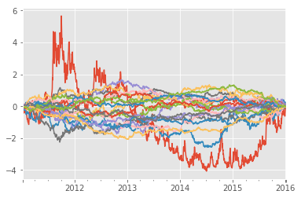

```python
risk_model['factor_returns'] = factor_returns(
    pca,
    five_year_returns,
    five_year_returns.index,
    np.arange(num_factor_exposures))

risk_model['factor_returns'].cumsum().plot(legend=None)
```

## Factor Covariance Matrix

Implement `factor_cov_matrix` to get the factor covariance matrix.

```python
def factor_cov_matrix(factor_returns, ann_factor):
    """
    Get the factor covariance matrix

    Parameters
    ----------
    factor_returns : DataFrame
        Factor returns
    ann_factor : int
        Annualization factor

    Returns
    -------
    factor_cov_matrix : 2 dimensional Ndarray
        Factor covariance matrix
    """

    #TODO: Implement function
    factor_cov_matrix = np.diag(factor_returns.var(axis=0, ddof=1)*ann_factor)

    return factor_cov_matrix


project_tests.test_factor_cov_matrix(factor_cov_matrix)
```

```
Tests Passed
```

### View Data

```python
ann_factor = 252
risk_model['factor_cov_matrix'] = factor_cov_matrix(risk_model['factor_returns'], ann_factor)

risk_model['factor_cov_matrix']
```

```
array([[14.01830425,  0.        ,  0.        ,  0.        ,  0.        ,
         0.        ,  0.        ,  0.        ,  0.        ,  0.        ,
         0.        ,  0.        ,  0.        ,  0.        ,  0.        ,
         0.        ,  0.        ,  0.        ,  0.        ,  0.        ],
       [ 0.        ,  1.10591127,  0.        ,  0.        ,  0.        ,
         0.        ,  0.        ,  0.        ,  0.        ,  0.        ,
         0.        ,  0.        ,  0.        ,  0.        ,  0.        ,
         0.        ,  0.        ,  0.        ,  0.        ,  0.        ],
       [ 0.        ,  0.        ,  0.77099145,  0.        ,  0.        ,
         0.        ,  0.        ,  0.        ,  0.        ,  0.        ,
         0.        ,  0.        ,  0.        ,  0.        ,  0.        ,
         0.        ,  0.        ,  0.        ,  0.        ,  0.        ],
       [ 0.        ,  0.        ,  0.        ,  0.61798821,  0.        ,
         0.        ,  0.        ,  0.        ,  0.        ,  0.        ,
         0.        ,  0.        ,  0.        ,  0.        ,  0.        ,
         0.        ,  0.        ,  0.        ,  0.        ,  0.        ],
       [ 0.        ,  0.        ,  0.        ,  0.        ,  0.47589087,
         0.        ,  0.        ,  0.        ,  0.        ,  0.        ,
         0.        ,  0.        ,  0.        ,  0.        ,  0.        ,
         0.        ,  0.        ,  0.        ,  0.        ,  0.        ],
       [ 0.        ,  0.        ,  0.        ,  0.        ,  0.        ,
         0.43653315,  0.        ,  0.        ,  0.        ,  0.        ,
         0.        ,  0.        ,  0.        ,  0.        ,  0.        ,
         0.        ,  0.        ,  0.        ,  0.        ,  0.        ],
       [ 0.        ,  0.        ,  0.        ,  0.        ,  0.        ,
         0.        ,  0.3873247 ,  0.        ,  0.        ,  0.        ,
         0.        ,  0.        ,  0.        ,  0.        ,  0.        ,
         0.        ,  0.        ,  0.        ,  0.        ,  0.        ],
       [ 0.        ,  0.        ,  0.        ,  0.        ,  0.        ,
         0.        ,  0.        ,  0.34930223,  0.        ,  0.        ,
         0.        ,  0.        ,  0.        ,  0.        ,  0.        ,
         0.        ,  0.        ,  0.        ,  0.        ,  0.        ],
       [ 0.        ,  0.        ,  0.        ,  0.        ,  0.        ,
         0.        ,  0.        ,  0.        ,  0.34350302,  0.        ,
         0.        ,  0.        ,  0.        ,  0.        ,  0.        ,
         0.        ,  0.        ,  0.        ,  0.        ,  0.        ],
       [ 0.        ,  0.        ,  0.        ,  0.        ,  0.        ,
         0.        ,  0.        ,  0.        ,  0.        ,  0.31674219,
         0.        ,  0.        ,  0.        ,  0.        ,  0.        ,
         0.        ,  0.        ,  0.        ,  0.        ,  0.        ],
```

[output cut: 25 more lines]

```
         0.        ,  0.        ,  0.        ,  0.        ,  0.        ,
         0.        ,  0.        ,  0.        ,  0.        ,  0.        ,
         0.        ,  0.20845473,  0.        ,  0.        ,  0.        ],
       [ 0.        ,  0.        ,  0.        ,  0.        ,  0.        ,
         0.        ,  0.        ,  0.        ,  0.        ,  0.        ,
         0.        ,  0.        ,  0.        ,  0.        ,  0.        ,
         0.        ,  0.        ,  0.19480492,  0.        ,  0.        ],
       [ 0.        ,  0.        ,  0.        ,  0.        ,  0.        ,
         0.        ,  0.        ,  0.        ,  0.        ,  0.        ,
         0.        ,  0.        ,  0.        ,  0.        ,  0.        ,
         0.        ,  0.        ,  0.        ,  0.19126517,  0.        ],
       [ 0.        ,  0.        ,  0.        ,  0.        ,  0.        ,
         0.        ,  0.        ,  0.        ,  0.        ,  0.        ,
         0.        ,  0.        ,  0.        ,  0.        ,  0.        ,
         0.        ,  0.        ,  0.        ,  0.        ,  0.18725609]])
```

## Idiosyncratic Variance Matrix

Implement `idiosyncratic_var_matrix` to get the idiosyncratic variance matrix.

```python
def idiosyncratic_var_matrix(returns, factor_returns, factor_betas, ann_factor):
    """
    Get the idiosyncratic variance matrix

    Parameters
    ----------
    returns : DataFrame
        Returns for each ticker and date
    factor_returns : DataFrame
        Factor returns
    factor_betas : DataFrame
        Factor betas
    ann_factor : int
        Annualization factor

    Returns
    -------
    idiosyncratic_var_matrix : DataFrame
        Idiosyncratic variance matrix
    """

    #TODO: Implement function
    data = np.dot(factor_returns, factor_betas.T)
    indices = returns.index
    columns = returns.columns

    common_returns = pd.DataFrame(data=data, index=indices, columns=columns)

    idiosyncratic_returns = returns - common_returns

    idiosyncratic_var_matrix = pd.DataFrame(data=factor_cov_matrix(idiosyncratic_returns, ann_factor), index=columns, columns=columns)

    return idiosyncratic_var_matrix


project_tests.test_idiosyncratic_var_matrix(idiosyncratic_var_matrix)
```

```
Tests Passed
```

### View Data

```python
risk_model['idiosyncratic_var_matrix'] = idiosyncratic_var_matrix(five_year_returns, risk_model['factor_returns'], risk_model['factor_betas'], ann_factor)

risk_model['idiosyncratic_var_matrix']
```

|  | Equity(0 [A]) | Equity(1 [AAL]) | Equity(2 [AAP]) | Equity(3 [AAPL]) | Equity(4 [ABBV]) | Equity(5 [ABC]) | Equity(6 [ABT]) | Equity(7 [ACN]) | Equity(8 [ADBE]) | Equity(9 [ADI]) | ... | Equity(481 [XL]) | Equity(482 [XLNX]) | Equity(483 [XOM]) | Equity(484 [XRAY]) | Equity(485 [XRX]) | Equity(486 [XYL]) | Equity(487 [YUM]) | Equity(488 [ZBH]) | Equity(489 [ZION]) | Equity(490 [ZTS]) |
| --- | --- | --- | --- | --- | --- | --- | --- | --- | --- | --- | --- | --- | --- | --- | --- | --- | --- | --- | --- | --- | --- |
| Equity(0 [A]) | 0.02274345 | 0.00000000 | 0.00000000 | 0.00000000 | 0.00000000 | 0.00000000 | 0.00000000 | 0.00000000 | 0.00000000 | 0.00000000 | ... | 0.00000000 | 0.00000000 | 0.00000000 | 0.00000000 | 0.00000000 | 0.00000000 | 0.00000000 | 0.00000000 | 0.00000000 | 0.00000000 |
| Equity(1 [AAL]) | 0.00000000 | 0.05194219 | 0.00000000 | 0.00000000 | 0.00000000 | 0.00000000 | 0.00000000 | 0.00000000 | 0.00000000 | 0.00000000 | ... | 0.00000000 | 0.00000000 | 0.00000000 | 0.00000000 | 0.00000000 | 0.00000000 | 0.00000000 | 0.00000000 | 0.00000000 | 0.00000000 |
| Equity(2 [AAP]) | 0.00000000 | 0.00000000 | 0.05435508 | 0.00000000 | 0.00000000 | 0.00000000 | 0.00000000 | 0.00000000 | 0.00000000 | 0.00000000 | ... | 0.00000000 | 0.00000000 | 0.00000000 | 0.00000000 | 0.00000000 | 0.00000000 | 0.00000000 | 0.00000000 | 0.00000000 | 0.00000000 |
| Equity(3 [AAPL]) | 0.00000000 | 0.00000000 | 0.00000000 | 0.04805710 | 0.00000000 | 0.00000000 | 0.00000000 | 0.00000000 | 0.00000000 | 0.00000000 | ... | 0.00000000 | 0.00000000 | 0.00000000 | 0.00000000 | 0.00000000 | 0.00000000 | 0.00000000 | 0.00000000 | 0.00000000 | 0.00000000 |
| Equity(4 [ABBV]) | 0.00000000 | 0.00000000 | 0.00000000 | 0.00000000 | 0.03042784 | 0.00000000 | 0.00000000 | 0.00000000 | 0.00000000 | 0.00000000 | ... | 0.00000000 | 0.00000000 | 0.00000000 | 0.00000000 | 0.00000000 | 0.00000000 | 0.00000000 | 0.00000000 | 0.00000000 | 0.00000000 |
| Equity(5 [ABC]) | 0.00000000 | 0.00000000 | 0.00000000 | 0.00000000 | 0.00000000 | 0.01855981 | 0.00000000 | 0.00000000 | 0.00000000 | 0.00000000 | ... | 0.00000000 | 0.00000000 | 0.00000000 | 0.00000000 | 0.00000000 | 0.00000000 | 0.00000000 | 0.00000000 | 0.00000000 | 0.00000000 |
| Equity(6 [ABT]) | 0.00000000 | 0.00000000 | 0.00000000 | 0.00000000 | 0.00000000 | 0.00000000 | 0.01482695 | 0.00000000 | 0.00000000 | 0.00000000 | ... | 0.00000000 | 0.00000000 | 0.00000000 | 0.00000000 | 0.00000000 | 0.00000000 | 0.00000000 | 0.00000000 | 0.00000000 | 0.00000000 |
| Equity(7 [ACN]) | 0.00000000 | 0.00000000 | 0.00000000 | 0.00000000 | 0.00000000 | 0.00000000 | 0.00000000 | 0.02179205 | 0.00000000 | 0.00000000 | ... | 0.00000000 | 0.00000000 | 0.00000000 | 0.00000000 | 0.00000000 | 0.00000000 | 0.00000000 | 0.00000000 | 0.00000000 | 0.00000000 |
| Equity(8 [ADBE]) | 0.00000000 | 0.00000000 | 0.00000000 | 0.00000000 | 0.00000000 | 0.00000000 | 0.00000000 | 0.00000000 | 0.03444868 | 0.00000000 | ... | 0.00000000 | 0.00000000 | 0.00000000 | 0.00000000 | 0.00000000 | 0.00000000 | 0.00000000 | 0.00000000 | 0.00000000 | 0.00000000 |
| Equity(9 [ADI]) | 0.00000000 | 0.00000000 | 0.00000000 | 0.00000000 | 0.00000000 | 0.00000000 | 0.00000000 | 0.00000000 | 0.00000000 | 0.01899917 | ... | 0.00000000 | 0.00000000 | 0.00000000 | 0.00000000 | 0.00000000 | 0.00000000 | 0.00000000 | 0.00000000 | 0.00000000 | 0.00000000 |
| Equity(10 [ADM]) | 0.00000000 | 0.00000000 | 0.00000000 | 0.00000000 | 0.00000000 | 0.00000000 | 0.00000000 | 0.00000000 | 0.00000000 | 0.00000000 | ... | 0.00000000 | 0.00000000 | 0.00000000 | 0.00000000 | 0.00000000 | 0.00000000 | 0.00000000 | 0.00000000 | 0.00000000 | 0.00000000 |
| Equity(11 [ADP]) | 0.00000000 | 0.00000000 | 0.00000000 | 0.00000000 | 0.00000000 | 0.00000000 | 0.00000000 | 0.00000000 | 0.00000000 | 0.00000000 | ... | 0.00000000 | 0.00000000 | 0.00000000 | 0.00000000 | 0.00000000 | 0.00000000 | 0.00000000 | 0.00000000 | 0.00000000 | 0.00000000 |
| Equity(12 [ADS]) | 0.00000000 | 0.00000000 | 0.00000000 | 0.00000000 | 0.00000000 | 0.00000000 | 0.00000000 | 0.00000000 | 0.00000000 | 0.00000000 | ... | 0.00000000 | 0.00000000 | 0.00000000 | 0.00000000 | 0.00000000 | 0.00000000 | 0.00000000 | 0.00000000 | 0.00000000 | 0.00000000 |
| Equity(13 [ADSK]) | 0.00000000 | 0.00000000 | 0.00000000 | 0.00000000 | 0.00000000 | 0.00000000 | 0.00000000 | 0.00000000 | 0.00000000 | 0.00000000 | ... | 0.00000000 | 0.00000000 | 0.00000000 | 0.00000000 | 0.00000000 | 0.00000000 | 0.00000000 | 0.00000000 | 0.00000000 | 0.00000000 |
| Equity(14 [AEE]) | 0.00000000 | 0.00000000 | 0.00000000 | 0.00000000 | 0.00000000 | 0.00000000 | 0.00000000 | 0.00000000 | 0.00000000 | 0.00000000 | ... | 0.00000000 | 0.00000000 | 0.00000000 | 0.00000000 | 0.00000000 | 0.00000000 | 0.00000000 | 0.00000000 | 0.00000000 | 0.00000000 |
| Equity(15 [AEP]) | 0.00000000 | 0.00000000 | 0.00000000 | 0.00000000 | 0.00000000 | 0.00000000 | 0.00000000 | 0.00000000 | 0.00000000 | 0.00000000 | ... | 0.00000000 | 0.00000000 | 0.00000000 | 0.00000000 | 0.00000000 | 0.00000000 | 0.00000000 | 0.00000000 | 0.00000000 | 0.00000000 |
| Equity(16 [AES]) | 0.00000000 | 0.00000000 | 0.00000000 | 0.00000000 | 0.00000000 | 0.00000000 | 0.00000000 | 0.00000000 | 0.00000000 | 0.00000000 | ... | 0.00000000 | 0.00000000 | 0.00000000 | 0.00000000 | 0.00000000 | 0.00000000 | 0.00000000 | 0.00000000 | 0.00000000 | 0.00000000 |
| Equity(17 [AET]) | 0.00000000 | 0.00000000 | 0.00000000 | 0.00000000 | 0.00000000 | 0.00000000 | 0.00000000 | 0.00000000 | 0.00000000 | 0.00000000 | ... | 0.00000000 | 0.00000000 | 0.00000000 | 0.00000000 | 0.00000000 | 0.00000000 | 0.00000000 | 0.00000000 | 0.00000000 | 0.00000000 |
| Equity(18 [AFL]) | 0.00000000 | 0.00000000 | 0.00000000 | 0.00000000 | 0.00000000 | 0.00000000 | 0.00000000 | 0.00000000 | 0.00000000 | 0.00000000 | ... | 0.00000000 | 0.00000000 | 0.00000000 | 0.00000000 | 0.00000000 | 0.00000000 | 0.00000000 | 0.00000000 | 0.00000000 | 0.00000000 |
| Equity(19 [AGN]) | 0.00000000 | 0.00000000 | 0.00000000 | 0.00000000 | 0.00000000 | 0.00000000 | 0.00000000 | 0.00000000 | 0.00000000 | 0.00000000 | ... | 0.00000000 | 0.00000000 | 0.00000000 | 0.00000000 | 0.00000000 | 0.00000000 | 0.00000000 | 0.00000000 | 0.00000000 | 0.00000000 |
| Equity(20 [AIG]) | 0.00000000 | 0.00000000 | 0.00000000 | 0.00000000 | 0.00000000 | 0.00000000 | 0.00000000 | 0.00000000 | 0.00000000 | 0.00000000 | ... | 0.00000000 | 0.00000000 | 0.00000000 | 0.00000000 | 0.00000000 | 0.00000000 | 0.00000000 | 0.00000000 | 0.00000000 | 0.00000000 |
| Equity(21 [AIV]) | 0.00000000 | 0.00000000 | 0.00000000 | 0.00000000 | 0.00000000 | 0.00000000 | 0.00000000 | 0.00000000 | 0.00000000 | 0.00000000 | ... | 0.00000000 | 0.00000000 | 0.00000000 | 0.00000000 | 0.00000000 | 0.00000000 | 0.00000000 | 0.00000000 | 0.00000000 | 0.00000000 |
| Equity(22 [AIZ]) | 0.00000000 | 0.00000000 | 0.00000000 | 0.00000000 | 0.00000000 | 0.00000000 | 0.00000000 | 0.00000000 | 0.00000000 | 0.00000000 | ... | 0.00000000 | 0.00000000 | 0.00000000 | 0.00000000 | 0.00000000 | 0.00000000 | 0.00000000 | 0.00000000 | 0.00000000 | 0.00000000 |
| Equity(23 [AJG]) | 0.00000000 | 0.00000000 | 0.00000000 | 0.00000000 | 0.00000000 | 0.00000000 | 0.00000000 | 0.00000000 | 0.00000000 | 0.00000000 | ... | 0.00000000 | 0.00000000 | 0.00000000 | 0.00000000 | 0.00000000 | 0.00000000 | 0.00000000 | 0.00000000 | 0.00000000 | 0.00000000 |
| Equity(24 [AKAM]) | 0.00000000 | 0.00000000 | 0.00000000 | 0.00000000 | 0.00000000 | 0.00000000 | 0.00000000 | 0.00000000 | 0.00000000 | 0.00000000 | ... | 0.00000000 | 0.00000000 | 0.00000000 | 0.00000000 | 0.00000000 | 0.00000000 | 0.00000000 | 0.00000000 | 0.00000000 | 0.00000000 |
| Equity(25 [ALB]) | 0.00000000 | 0.00000000 | 0.00000000 | 0.00000000 | 0.00000000 | 0.00000000 | 0.00000000 | 0.00000000 | 0.00000000 | 0.00000000 | ... | 0.00000000 | 0.00000000 | 0.00000000 | 0.00000000 | 0.00000000 | 0.00000000 | 0.00000000 | 0.00000000 | 0.00000000 | 0.00000000 |
| Equity(26 [ALGN]) | 0.00000000 | 0.00000000 | 0.00000000 | 0.00000000 | 0.00000000 | 0.00000000 | 0.00000000 | 0.00000000 | 0.00000000 | 0.00000000 | ... | 0.00000000 | 0.00000000 | 0.00000000 | 0.00000000 | 0.00000000 | 0.00000000 | 0.00000000 | 0.00000000 | 0.00000000 | 0.00000000 |
| Equity(27 [ALK]) | 0.00000000 | 0.00000000 | 0.00000000 | 0.00000000 | 0.00000000 | 0.00000000 | 0.00000000 | 0.00000000 | 0.00000000 | 0.00000000 | ... | 0.00000000 | 0.00000000 | 0.00000000 | 0.00000000 | 0.00000000 | 0.00000000 | 0.00000000 | 0.00000000 | 0.00000000 | 0.00000000 |
| Equity(28 [ALL]) | 0.00000000 | 0.00000000 | 0.00000000 | 0.00000000 | 0.00000000 | 0.00000000 | 0.00000000 | 0.00000000 | 0.00000000 | 0.00000000 | ... | 0.00000000 | 0.00000000 | 0.00000000 | 0.00000000 | 0.00000000 | 0.00000000 | 0.00000000 | 0.00000000 | 0.00000000 | 0.00000000 |
| Equity(29 [ALLE]) | 0.00000000 | 0.00000000 | 0.00000000 | 0.00000000 | 0.00000000 | 0.00000000 | 0.00000000 | 0.00000000 | 0.00000000 | 0.00000000 | ... | 0.00000000 | 0.00000000 | 0.00000000 | 0.00000000 | 0.00000000 | 0.00000000 | 0.00000000 | 0.00000000 | 0.00000000 | 0.00000000 |
| ... | ... | ... | ... | ... | ... | ... | ... | ... | ... | ... | ... | ... | ... | ... | ... | ... | ... | ... | ... | ... | ... |
| Equity(460 [VRSN]) | 0.00000000 | 0.00000000 | 0.00000000 | 0.00000000 | 0.00000000 | 0.00000000 | 0.00000000 | 0.00000000 | 0.00000000 | 0.00000000 | ... | 0.00000000 | 0.00000000 | 0.00000000 | 0.00000000 | 0.00000000 | 0.00000000 | 0.00000000 | 0.00000000 | 0.00000000 | 0.00000000 |
| Equity(461 [VRTX]) | 0.00000000 | 0.00000000 | 0.00000000 | 0.00000000 | 0.00000000 | 0.00000000 | 0.00000000 | 0.00000000 | 0.00000000 | 0.00000000 | ... | 0.00000000 | 0.00000000 | 0.00000000 | 0.00000000 | 0.00000000 | 0.00000000 | 0.00000000 | 0.00000000 | 0.00000000 | 0.00000000 |
| Equity(462 [VTR]) | 0.00000000 | 0.00000000 | 0.00000000 | 0.00000000 | 0.00000000 | 0.00000000 | 0.00000000 | 0.00000000 | 0.00000000 | 0.00000000 | ... | 0.00000000 | 0.00000000 | 0.00000000 | 0.00000000 | 0.00000000 | 0.00000000 | 0.00000000 | 0.00000000 | 0.00000000 | 0.00000000 |
| Equity(463 [VZ]) | 0.00000000 | 0.00000000 | 0.00000000 | 0.00000000 | 0.00000000 | 0.00000000 | 0.00000000 | 0.00000000 | 0.00000000 | 0.00000000 | ... | 0.00000000 | 0.00000000 | 0.00000000 | 0.00000000 | 0.00000000 | 0.00000000 | 0.00000000 | 0.00000000 | 0.00000000 | 0.00000000 |
| Equity(464 [WAT]) | 0.00000000 | 0.00000000 | 0.00000000 | 0.00000000 | 0.00000000 | 0.00000000 | 0.00000000 | 0.00000000 | 0.00000000 | 0.00000000 | ... | 0.00000000 | 0.00000000 | 0.00000000 | 0.00000000 | 0.00000000 | 0.00000000 | 0.00000000 | 0.00000000 | 0.00000000 | 0.00000000 |
| Equity(465 [WBA]) | 0.00000000 | 0.00000000 | 0.00000000 | 0.00000000 | 0.00000000 | 0.00000000 | 0.00000000 | 0.00000000 | 0.00000000 | 0.00000000 | ... | 0.00000000 | 0.00000000 | 0.00000000 | 0.00000000 | 0.00000000 | 0.00000000 | 0.00000000 | 0.00000000 | 0.00000000 | 0.00000000 |
| Equity(466 [WDC]) | 0.00000000 | 0.00000000 | 0.00000000 | 0.00000000 | 0.00000000 | 0.00000000 | 0.00000000 | 0.00000000 | 0.00000000 | 0.00000000 | ... | 0.00000000 | 0.00000000 | 0.00000000 | 0.00000000 | 0.00000000 | 0.00000000 | 0.00000000 | 0.00000000 | 0.00000000 | 0.00000000 |
| Equity(467 [WEC]) | 0.00000000 | 0.00000000 | 0.00000000 | 0.00000000 | 0.00000000 | 0.00000000 | 0.00000000 | 0.00000000 | 0.00000000 | 0.00000000 | ... | 0.00000000 | 0.00000000 | 0.00000000 | 0.00000000 | 0.00000000 | 0.00000000 | 0.00000000 | 0.00000000 | 0.00000000 | 0.00000000 |
| Equity(468 [WFC]) | 0.00000000 | 0.00000000 | 0.00000000 | 0.00000000 | 0.00000000 | 0.00000000 | 0.00000000 | 0.00000000 | 0.00000000 | 0.00000000 | ... | 0.00000000 | 0.00000000 | 0.00000000 | 0.00000000 | 0.00000000 | 0.00000000 | 0.00000000 | 0.00000000 | 0.00000000 | 0.00000000 |
| Equity(469 [WHR]) | 0.00000000 | 0.00000000 | 0.00000000 | 0.00000000 | 0.00000000 | 0.00000000 | 0.00000000 | 0.00000000 | 0.00000000 | 0.00000000 | ... | 0.00000000 | 0.00000000 | 0.00000000 | 0.00000000 | 0.00000000 | 0.00000000 | 0.00000000 | 0.00000000 | 0.00000000 | 0.00000000 |
| Equity(471 [WM]) | 0.00000000 | 0.00000000 | 0.00000000 | 0.00000000 | 0.00000000 | 0.00000000 | 0.00000000 | 0.00000000 | 0.00000000 | 0.00000000 | ... | 0.00000000 | 0.00000000 | 0.00000000 | 0.00000000 | 0.00000000 | 0.00000000 | 0.00000000 | 0.00000000 | 0.00000000 | 0.00000000 |
| Equity(472 [WMB]) | 0.00000000 | 0.00000000 | 0.00000000 | 0.00000000 | 0.00000000 | 0.00000000 | 0.00000000 | 0.00000000 | 0.00000000 | 0.00000000 | ... | 0.00000000 | 0.00000000 | 0.00000000 | 0.00000000 | 0.00000000 | 0.00000000 | 0.00000000 | 0.00000000 | 0.00000000 | 0.00000000 |
| Equity(473 [WMT]) | 0.00000000 | 0.00000000 | 0.00000000 | 0.00000000 | 0.00000000 | 0.00000000 | 0.00000000 | 0.00000000 | 0.00000000 | 0.00000000 | ... | 0.00000000 | 0.00000000 | 0.00000000 | 0.00000000 | 0.00000000 | 0.00000000 | 0.00000000 | 0.00000000 | 0.00000000 | 0.00000000 |
| Equity(474 [WRK]) | 0.00000000 | 0.00000000 | 0.00000000 | 0.00000000 | 0.00000000 | 0.00000000 | 0.00000000 | 0.00000000 | 0.00000000 | 0.00000000 | ... | 0.00000000 | 0.00000000 | 0.00000000 | 0.00000000 | 0.00000000 | 0.00000000 | 0.00000000 | 0.00000000 | 0.00000000 | 0.00000000 |
| Equity(475 [WU]) | 0.00000000 | 0.00000000 | 0.00000000 | 0.00000000 | 0.00000000 | 0.00000000 | 0.00000000 | 0.00000000 | 0.00000000 | 0.00000000 | ... | 0.00000000 | 0.00000000 | 0.00000000 | 0.00000000 | 0.00000000 | 0.00000000 | 0.00000000 | 0.00000000 | 0.00000000 | 0.00000000 |
| Equity(476 [WY]) | 0.00000000 | 0.00000000 | 0.00000000 | 0.00000000 | 0.00000000 | 0.00000000 | 0.00000000 | 0.00000000 | 0.00000000 | 0.00000000 | ... | 0.00000000 | 0.00000000 | 0.00000000 | 0.00000000 | 0.00000000 | 0.00000000 | 0.00000000 | 0.00000000 | 0.00000000 | 0.00000000 |
| Equity(477 [WYN]) | 0.00000000 | 0.00000000 | 0.00000000 | 0.00000000 | 0.00000000 | 0.00000000 | 0.00000000 | 0.00000000 | 0.00000000 | 0.00000000 | ... | 0.00000000 | 0.00000000 | 0.00000000 | 0.00000000 | 0.00000000 | 0.00000000 | 0.00000000 | 0.00000000 | 0.00000000 | 0.00000000 |
| Equity(478 [WYNN]) | 0.00000000 | 0.00000000 | 0.00000000 | 0.00000000 | 0.00000000 | 0.00000000 | 0.00000000 | 0.00000000 | 0.00000000 | 0.00000000 | ... | 0.00000000 | 0.00000000 | 0.00000000 | 0.00000000 | 0.00000000 | 0.00000000 | 0.00000000 | 0.00000000 | 0.00000000 | 0.00000000 |
| Equity(479 [XEC]) | 0.00000000 | 0.00000000 | 0.00000000 | 0.00000000 | 0.00000000 | 0.00000000 | 0.00000000 | 0.00000000 | 0.00000000 | 0.00000000 | ... | 0.00000000 | 0.00000000 | 0.00000000 | 0.00000000 | 0.00000000 | 0.00000000 | 0.00000000 | 0.00000000 | 0.00000000 | 0.00000000 |
| Equity(480 [XEL]) | 0.00000000 | 0.00000000 | 0.00000000 | 0.00000000 | 0.00000000 | 0.00000000 | 0.00000000 | 0.00000000 | 0.00000000 | 0.00000000 | ... | 0.00000000 | 0.00000000 | 0.00000000 | 0.00000000 | 0.00000000 | 0.00000000 | 0.00000000 | 0.00000000 | 0.00000000 | 0.00000000 |
| Equity(481 [XL]) | 0.00000000 | 0.00000000 | 0.00000000 | 0.00000000 | 0.00000000 | 0.00000000 | 0.00000000 | 0.00000000 | 0.00000000 | 0.00000000 | ... | 0.02053561 | 0.00000000 | 0.00000000 | 0.00000000 | 0.00000000 | 0.00000000 | 0.00000000 | 0.00000000 | 0.00000000 | 0.00000000 |
| Equity(482 [XLNX]) | 0.00000000 | 0.00000000 | 0.00000000 | 0.00000000 | 0.00000000 | 0.00000000 | 0.00000000 | 0.00000000 | 0.00000000 | 0.00000000 | ... | 0.00000000 | 0.02686438 | 0.00000000 | 0.00000000 | 0.00000000 | 0.00000000 | 0.00000000 | 0.00000000 | 0.00000000 | 0.00000000 |
| Equity(483 [XOM]) | 0.00000000 | 0.00000000 | 0.00000000 | 0.00000000 | 0.00000000 | 0.00000000 | 0.00000000 | 0.00000000 | 0.00000000 | 0.00000000 | ... | 0.00000000 | 0.00000000 | 0.01060686 | 0.00000000 | 0.00000000 | 0.00000000 | 0.00000000 | 0.00000000 | 0.00000000 | 0.00000000 |
| Equity(484 [XRAY]) | 0.00000000 | 0.00000000 | 0.00000000 | 0.00000000 | 0.00000000 | 0.00000000 | 0.00000000 | 0.00000000 | 0.00000000 | 0.00000000 | ... | 0.00000000 | 0.00000000 | 0.00000000 | 0.01538395 | 0.00000000 | 0.00000000 | 0.00000000 | 0.00000000 | 0.00000000 | 0.00000000 |
| Equity(485 [XRX]) | 0.00000000 | 0.00000000 | 0.00000000 | 0.00000000 | 0.00000000 | 0.00000000 | 0.00000000 | 0.00000000 | 0.00000000 | 0.00000000 | ... | 0.00000000 | 0.00000000 | 0.00000000 | 0.00000000 | 0.03950011 | 0.00000000 | 0.00000000 | 0.00000000 | 0.00000000 | 0.00000000 |
| Equity(486 [XYL]) | 0.00000000 | 0.00000000 | 0.00000000 | 0.00000000 | 0.00000000 | 0.00000000 | 0.00000000 | 0.00000000 | 0.00000000 | 0.00000000 | ... | 0.00000000 | 0.00000000 | 0.00000000 | 0.00000000 | 0.00000000 | 0.03194146 | 0.00000000 | 0.00000000 | 0.00000000 | 0.00000000 |
| Equity(487 [YUM]) | 0.00000000 | 0.00000000 | 0.00000000 | 0.00000000 | 0.00000000 | 0.00000000 | 0.00000000 | 0.00000000 | 0.00000000 | 0.00000000 | ... | 0.00000000 | 0.00000000 | 0.00000000 | 0.00000000 | 0.00000000 | 0.00000000 | 0.04389013 | 0.00000000 | 0.00000000 | 0.00000000 |
| Equity(488 [ZBH]) | 0.00000000 | 0.00000000 | 0.00000000 | 0.00000000 | 0.00000000 | 0.00000000 | 0.00000000 | 0.00000000 | 0.00000000 | 0.00000000 | ... | 0.00000000 | 0.00000000 | 0.00000000 | 0.00000000 | 0.00000000 | 0.00000000 | 0.00000000 | 0.02234798 | 0.00000000 | 0.00000000 |
| Equity(489 [ZION]) | 0.00000000 | 0.00000000 | 0.00000000 | 0.00000000 | 0.00000000 | 0.00000000 | 0.00000000 | 0.00000000 | 0.00000000 | 0.00000000 | ... | 0.00000000 | 0.00000000 | 0.00000000 | 0.00000000 | 0.00000000 | 0.00000000 | 0.00000000 | 0.00000000 | 0.02339072 | 0.00000000 |
| Equity(490 [ZTS]) | 0.00000000 | 0.00000000 | 0.00000000 | 0.00000000 | 0.00000000 | 0.00000000 | 0.00000000 | 0.00000000 | 0.00000000 | 0.00000000 | ... | 0.00000000 | 0.00000000 | 0.00000000 | 0.00000000 | 0.00000000 | 0.00000000 | 0.00000000 | 0.00000000 | 0.00000000 | 0.02737254 |

490 rows × 490 columns

## Idiosyncratic Variance Vector

Implement `idiosyncratic_var_vector` to get the idiosyncratic variance Vector.

```python
def idiosyncratic_var_vector(returns, idiosyncratic_var_matrix):
    """
    Get the idiosyncratic variance vector

    Parameters
    ----------
    returns : DataFrame
        Returns for each ticker and date
    idiosyncratic_var_matrix : DataFrame
        Idiosyncratic variance matrix

    Returns
    -------
    idiosyncratic_var_vector : DataFrame
        Idiosyncratic variance Vector
    """

    #TODO: Implement function
    idiosyncratic_var_vector = pd.DataFrame(data=np.diag(idiosyncratic_var_matrix), index=returns.columns)

    return idiosyncratic_var_vector


project_tests.test_idiosyncratic_var_vector(idiosyncratic_var_vector)
```

```
Tests Passed
```

### View Data

```python
risk_model['idiosyncratic_var_vector'] = idiosyncratic_var_vector(five_year_returns, risk_model['idiosyncratic_var_matrix'])

risk_model['idiosyncratic_var_vector']
```

|  | 0 |
| --- | --- |
| Equity(0 [A]) | 0.02274345 |
| Equity(1 [AAL]) | 0.05194219 |
| Equity(2 [AAP]) | 0.05435508 |
| Equity(3 [AAPL]) | 0.04805710 |
| Equity(4 [ABBV]) | 0.03042784 |
| Equity(5 [ABC]) | 0.01855981 |
| Equity(6 [ABT]) | 0.01482695 |
| Equity(7 [ACN]) | 0.02179205 |
| Equity(8 [ADBE]) | 0.03444868 |
| Equity(9 [ADI]) | 0.01899917 |
| Equity(10 [ADM]) | 0.02953796 |
| Equity(11 [ADP]) | 0.00828786 |
| Equity(12 [ADS]) | 0.02705582 |
| Equity(13 [ADSK]) | 0.05228426 |
| Equity(14 [AEE]) | 0.00962228 |
| Equity(15 [AEP]) | 0.00801014 |
| Equity(16 [AES]) | 0.03082031 |
| Equity(17 [AET]) | 0.03581929 |
| Equity(18 [AFL]) | 0.01895704 |
| Equity(19 [AGN]) | 0.04214957 |
| Equity(20 [AIG]) | 0.03320188 |
| Equity(21 [AIV]) | 0.01469704 |
| Equity(22 [AIZ]) | 0.02063594 |
| Equity(23 [AJG]) | 0.01158242 |
| Equity(24 [AKAM]) | 0.09697730 |
| Equity(25 [ALB]) | 0.04109919 |
| Equity(26 [ALGN]) | 0.10517035 |
| Equity(27 [ALK]) | 0.03391259 |
| Equity(28 [ALL]) | 0.01675530 |
| Equity(29 [ALLE]) | 0.01457742 |
| ... | ... |
| Equity(460 [VRSN]) | 0.04359801 |
| Equity(461 [VRTX]) | 0.01134007 |
| Equity(462 [VTR]) | 0.01240265 |
| Equity(463 [VZ]) | 0.01827579 |
| Equity(464 [WAT]) | 0.02521296 |
| Equity(465 [WBA]) | 0.04837649 |
| Equity(466 [WDC]) | 0.04274710 |
| Equity(467 [WEC]) | 0.00660665 |
| Equity(468 [WFC]) | 0.01139018 |
| Equity(469 [WHR]) | 0.05783390 |
| Equity(471 [WM]) | 0.01512309 |
| Equity(472 [WMB]) | 0.05873254 |
| Equity(473 [WMT]) | 0.01609357 |
| Equity(474 [WRK]) | 0.00836594 |
| Equity(475 [WU]) | 0.04774145 |
| Equity(476 [WY]) | 0.02648144 |
| Equity(477 [WYN]) | 0.02431327 |
| Equity(478 [WYNN]) | 0.05818694 |
| Equity(479 [XEC]) | 0.04865691 |
| Equity(480 [XEL]) | 0.00535278 |
| Equity(481 [XL]) | 0.02053561 |
| Equity(482 [XLNX]) | 0.02686438 |
| Equity(483 [XOM]) | 0.01060686 |
| Equity(484 [XRAY]) | 0.01538395 |
| Equity(485 [XRX]) | 0.03950011 |
| Equity(486 [XYL]) | 0.03194146 |
| Equity(487 [YUM]) | 0.04389013 |
| Equity(488 [ZBH]) | 0.02234798 |
| Equity(489 [ZION]) | 0.02339072 |
| Equity(490 [ZTS]) | 0.02737254 |

490 rows × 1 columns

## Predict using the Risk Model

Using the data we calculated in the risk model, implement `predict_portfolio_risk` to predict the portfolio risk using the formula $ \sqrt{X^{T}(BFB^{T} + S)X} $ where:

- $ X $ is the portfolio weights
- $ B $ is the factor betas
- $ F $ is the factor covariance matrix
- $ S $ is the idiosyncratic variance matrix

```python
def predict_portfolio_risk(factor_betas, factor_cov_matrix, idiosyncratic_var_matrix, weights):
    """
    Get the predicted portfolio risk

    Formula for predicted portfolio risk is sqrt(X.T(BFB.T + S)X) where:
      X is the portfolio weights
      B is the factor betas
      F is the factor covariance matrix
      S is the idiosyncratic variance matrix

    Parameters
    ----------
    factor_betas : DataFrame
        Factor betas
    factor_cov_matrix : 2 dimensional Ndarray
        Factor covariance matrix
    idiosyncratic_var_matrix : DataFrame
        Idiosyncratic variance matrix
    weights : DataFrame
        Portfolio weights

    Returns
    -------
    predicted_portfolio_risk : float
        Predicted portfolio risk
    """
    assert len(factor_cov_matrix.shape) == 2

    #TODO: Implement function
    X = weights.values
    B = factor_betas.values
    F = factor_cov_matrix
    S = idiosyncratic_var_matrix.values

    predicted_portfolio_risk = np.sqrt(X.T@(B@F@B.T + S)@X)[0][0]

    return predicted_portfolio_risk


project_tests.test_predict_portfolio_risk(predict_portfolio_risk)
```

```
Tests Passed
```

### View Data

Let's see what the portfolio risk would be if we had even weights across all stocks.

```python
all_weights = pd.DataFrame(np.repeat(1/len(universe_tickers), len(universe_tickers)), universe_tickers)

predict_portfolio_risk(
    risk_model['factor_betas'],
    risk_model['factor_cov_matrix'],
    risk_model['idiosyncratic_var_matrix'],
    all_weights)
```

```
0.1609483997355891
```

# Create Alpha Factors

With the profile risk calculated, it's time to start working on the alpha factors. In this project, we'll create the following factors:

- Momentum 1 Year Factor
- Mean Reversion 5 Day Sector Neutral Factor
- Mean Reversion 5 Day Sector Neutral Smoothed Factor
- Overnight Sentiment Factor
- Overnight Sentiment Smoothed Factor

## Momentum 1 Year Factor

Each factor will have a hypothesis that goes with it. For this factor, it is "Higher past 12-month (252 days) returns are proportional to future return." Using that hypothesis, we've generated this code:

```python
from zipline.pipeline.factors import Returns

def momentum_1yr(window_length, universe, sector):
    return Returns(window_length=window_length, mask=universe) \
        .demean(groupby=sector) \
        .rank() \
        .zscore()
```

## Mean Reversion 5 Day Sector Neutral Factor

Now it's time for you to implement `mean_reversion_5day_sector_neutral` using the hypothesis "Short-term outperformers(underperformers) compared to their sector will revert." Use the returns data from `universe`, demean using the sector data to partition, rank, then converted to a zscore.

```python
def mean_reversion_5day_sector_neutral(window_length, universe, sector):
    """
    Generate the mean reversion 5 day sector neutral factor

    Parameters
    ----------
    window_length : int
        Returns window length
    universe : Zipline Filter
        Universe of stocks filter
    sector : Zipline Classifier
        Sector classifier

    Returns
    -------
    factor : Zipline Factor
        Mean reversion 5 day sector neutral factor
    """

    #TODO: Implement function
    factor = -(Returns(window_length=window_length, mask=universe).demean(groupby=sector).rank().zscore())

    return factor


project_tests.test_mean_reversion_5day_sector_neutral(mean_reversion_5day_sector_neutral)
```

```
Running Integration Test on pipeline:
> start_dat = pd.Timestamp('2015-01-05', tz='utc')
> end_date = pd.Timestamp('2015-01-07', tz='utc')
> universe = AverageDollarVolume(window_length=2).top(4)
> factor = mean_reversion_5day_sector_neutral(
    window_length=3,
    universe=universe,
    sector=project_helper.Sector())
> pipeline.add(factor, 'Mean_Reversion_5Day_Sector_Neutral')
> engine.run_pipeline(pipeline, start_dat, end_date)

Tests Passed
```

### View Data

Let's see what some of the factor data looks like. For calculating factors, we'll be looking back 2 years.

**Note:** *Going back 2 years falls on a day when the market is closed. Pipeline package doesn't handle start or end dates that don't fall on days when the market is open. To fix this, we went back 2 extra days to fall on the next day when the market is open.*

```python
factor_start_date = universe_end_date - pd.DateOffset(years=2, days=2)
sector = project_helper.Sector()
window_length = 5

pipeline = Pipeline(screen=universe)
pipeline.add(
    mean_reversion_5day_sector_neutral(window_length, universe, sector),
    'Mean_Reversion_5Day_Sector_Neutral')
engine.run_pipeline(pipeline, factor_start_date, universe_end_date)
```

|  |  | Mean_Reversion_5Day_Sector_Neutral |
| --- | --- | --- |
| 2014-01-03 00:00:00+00:00 | Equity(0 [A]) | 0.85326482 |
|  | Equity(1 [AAL]) | 1.62630815 |
|  | Equity(2 [AAP]) | 0.64906469 |
|  | Equity(3 [AAPL]) | 1.40752230 |
|  | Equity(4 [ABBV]) | 1.45857233 |
|  | Equity(5 [ABC]) | 0.14585723 |
|  | Equity(6 [ABT]) | -0.30630019 |
|  | Equity(7 [ACN]) | 0.88243626 |
|  | Equity(8 [ADBE]) | -0.06563576 |
|  | Equity(9 [ADI]) | 1.67006532 |
|  | Equity(10 [ADM]) | 1.18144359 |
|  | Equity(11 [ADP]) | 0.24066444 |
|  | Equity(12 [ADS]) | -1.69194391 |
|  | Equity(13 [ADSK]) | -0.35735022 |
|  | Equity(14 [AEE]) | 0.34276450 |
|  | Equity(15 [AEP]) | -0.45215742 |
|  | Equity(16 [AES]) | 0.50320746 |
|  | Equity(17 [AET]) | 0.79492192 |
|  | Equity(18 [AFL]) | 1.15227214 |
|  | Equity(19 [AGN]) | -1.48045092 |
|  | Equity(20 [AIG]) | -0.27712874 |
|  | Equity(21 [AIV]) | -0.37922881 |
|  | Equity(22 [AIZ]) | 0.91890057 |
|  | Equity(23 [AJG]) | -0.82409337 |
|  | Equity(24 [AKAM]) | 1.22520076 |
|  | Equity(25 [ALB]) | 0.69282186 |
|  | Equity(26 [ALGN]) | 1.08663639 |
|  | Equity(27 [ALK]) | -1.30542224 |
|  | Equity(28 [ALL]) | -0.48862173 |
|  | Equity(29 [ALLE]) | 1.42940089 |
| ... | ... | ... |
| 2016-01-05 00:00:00+00:00 | Equity(460 [VRSN]) | 1.48614551 |
|  | Equity(461 [VRTX]) | -1.15826688 |
|  | Equity(462 [VTR]) | -1.55742347 |
|  | Equity(463 [VZ]) | -1.42912314 |
|  | Equity(464 [WAT]) | 0.47399845 |
|  | Equity(465 [WBA]) | 1.21528925 |
|  | Equity(466 [WDC]) | -1.59306245 |
|  | Equity(467 [WEC]) | -0.13899203 |
|  | Equity(468 [WFC]) | 0.35995371 |
|  | Equity(469 [WHR]) | -1.15113908 |
|  | Equity(471 [WM]) | 0.38133710 |
|  | Equity(472 [WMB]) | -1.69285160 |
|  | Equity(473 [WMT]) | -1.52891228 |
|  | Equity(474 [WRK]) | -1.32220619 |
|  | Equity(475 [WU]) | 0.54527641 |
|  | Equity(476 [WY]) | 0.08196966 |
|  | Equity(477 [WYN]) | 1.19390586 |
|  | Equity(478 [WYNN]) | -1.49327330 |
|  | Equity(479 [XEC]) | 0.30293134 |
|  | Equity(480 [XEL]) | 0.02494729 |
|  | Equity(481 [XL]) | 1.06560553 |
|  | Equity(482 [XLNX]) | 1.34358958 |
|  | Equity(483 [XOM]) | 1.60019024 |
|  | Equity(484 [XRAY]) | 1.22241705 |
|  | Equity(485 [XRX]) | 0.33144252 |
|  | Equity(486 [XYL]) | -0.13186423 |
|  | Equity(487 [YUM]) | 0.18175880 |
|  | Equity(488 [ZBH]) | -1.40061195 |
|  | Equity(489 [ZION]) | 0.52389302 |
|  | Equity(490 [ZTS]) | -0.93730520 |

244259 rows × 1 columns

## Mean Reversion 5 Day Sector Neutral Smoothed Factor

Taking the output of the previous factor, let's create a smoothed version. Implement `mean_reversion_5day_sector_neutral_smoothed` to generate a mean reversion 5 fay sector neutral smoothed factor. Call the `mean_reversion_5day_sector_neutral` function to get the unsmoothed factor, then use `SimpleMovingAverage` function to smooth it. You'll have to apply rank and zscore again.

```python
from zipline.pipeline.factors import SimpleMovingAverage

def mean_reversion_5day_sector_neutral_smoothed(window_length, universe, sector):
    """
    Generate the mean reversion 5 day sector neutral smoothed factor

    Parameters
    ----------
    window_length : int
        Returns window length
    universe : Zipline Filter
        Universe of stocks filter
    sector : Zipline Classifier
        Sector classifier

    Returns
    -------
    factor : Zipline Factor
        Mean reversion 5 day sector neutral smoothed factor
    """

    #TODO: Implement function
    factor_raw = mean_reversion_5day_sector_neutral(window_length, universe, sector)
    factor = SimpleMovingAverage(inputs=[factor_raw], window_length=window_length).rank().zscore()

    return factor


project_tests.test_mean_reversion_5day_sector_neutral_smoothed(mean_reversion_5day_sector_neutral_smoothed)
```

```
Running Integration Test on pipeline:
> start_dat = pd.Timestamp('2015-01-05', tz='utc')
> end_date = pd.Timestamp('2015-01-07', tz='utc')
> universe = AverageDollarVolume(window_length=2).top(4)
> factor = mean_reversion_5day_sector_neutral_smoothed(
    window_length=3,
    universe=universe,
    sector=project_helper.Sector())
> pipeline.add(factor, 'Mean_Reversion_5Day_Sector_Neutral_Smoothed')
> engine.run_pipeline(pipeline, start_dat, end_date)

Tests Passed
```

### View Data

Let's see what some of the smoothed data looks like.

```python
pipeline = Pipeline(screen=universe)
pipeline.add(
    mean_reversion_5day_sector_neutral_smoothed(5, universe, sector),
    'Mean_Reversion_5Day_Sector_Neutral_Smoothed')
engine.run_pipeline(pipeline, factor_start_date, universe_end_date)
```

|  |  | Mean_Reversion_5Day_Sector_Neutral_Smoothed |
| --- | --- | --- |
| 2014-01-03 00:00:00+00:00 | Equity(0 [A]) | 1.11580784 |
|  | Equity(1 [AAL]) | 1.72840822 |
|  | Equity(2 [AAP]) | 1.34188655 |
|  | Equity(3 [AAPL]) | 0.91160771 |
|  | Equity(4 [ABBV]) | 0.96265774 |
|  | Equity(5 [ABC]) | 0.77304334 |
|  | Equity(6 [ABT]) | 0.48862173 |
|  | Equity(7 [ACN]) | -0.45945029 |
|  | Equity(8 [ADBE]) | 0.81680051 |
|  | Equity(9 [ADI]) | 0.94807202 |
|  | Equity(10 [ADM]) | 0.73657903 |
|  | Equity(11 [ADP]) | 0.32088591 |
|  | Equity(12 [ADS]) | -1.59713671 |
|  | Equity(13 [ADSK]) | 0.08022148 |
|  | Equity(14 [AEE]) | 0.11668579 |
|  | Equity(15 [AEP]) | 0.21878585 |
|  | Equity(16 [AES]) | -0.75116475 |
|  | Equity(17 [AET]) | -1.09392925 |
|  | Equity(18 [AFL]) | -0.07292862 |
|  | Equity(19 [AGN]) | -0.37922881 |
|  | Equity(20 [AIG]) | 1.05017208 |
|  | Equity(21 [AIV]) | -0.14585723 |
|  | Equity(22 [AIZ]) | 0.67094327 |
|  | Equity(23 [AJG]) | -0.56155035 |
|  | Equity(24 [AKAM]) | 1.67735818 |
|  | Equity(25 [ALB]) | 1.35647227 |
|  | Equity(26 [ALGN]) | 1.32730082 |
|  | Equity(27 [ALK]) | 0.57613607 |
|  | Equity(28 [ALL]) | 0.02187859 |
|  | Equity(29 [ALLE]) | 1.65547960 |
| ... | ... | ... |
| 2016-01-05 00:00:00+00:00 | Equity(460 [VRSN]) | 1.12262790 |
|  | Equity(461 [VRTX]) | -1.62157363 |
|  | Equity(462 [VTR]) | -1.60731804 |
|  | Equity(463 [VZ]) | -1.68572380 |
|  | Equity(464 [WAT]) | -1.00858316 |
|  | Equity(465 [WBA]) | 0.98007198 |
|  | Equity(466 [WDC]) | -1.22241705 |
|  | Equity(467 [WEC]) | -0.78762148 |
|  | Equity(468 [WFC]) | 0.72347131 |
|  | Equity(469 [WHR]) | 0.37420930 |
|  | Equity(471 [WM]) | -0.53814861 |
|  | Equity(472 [WMB]) | -1.65721261 |
|  | Equity(473 [WMT]) | -1.41486754 |
|  | Equity(474 [WRK]) | -1.46476212 |
|  | Equity(475 [WU]) | 1.55742347 |
|  | Equity(476 [WY]) | -0.41697608 |
|  | Equity(477 [WYN]) | 0.48112624 |
|  | Equity(478 [WYNN]) | -1.36497297 |
|  | Equity(479 [XEC]) | -0.47399845 |
|  | Equity(480 [XEL]) | -0.95156079 |
|  | Equity(481 [XL]) | -0.76623809 |
|  | Equity(482 [XLNX]) | 1.47188991 |
|  | Equity(483 [XOM]) | 1.08698892 |
|  | Equity(484 [XRAY]) | 0.10335304 |
|  | Equity(485 [XRX]) | 0.98719977 |
|  | Equity(486 [XYL]) | 0.66644894 |
|  | Equity(487 [YUM]) | 1.07273333 |
|  | Equity(488 [ZBH]) | -0.13186423 |
|  | Equity(489 [ZION]) | 0.31718693 |
|  | Equity(490 [ZTS]) | 0.16750321 |

244259 rows × 1 columns

## Overnight Sentiment Factor

For this factor, were using the hypothesis from the paper [*Overnight Returns and Firm-Specific Investor Sentiment*](https://papers.ssrn.com/sol3/papers.cfm?abstract_id=2554010).

```python
from zipline.pipeline.data import USEquityPricing


class CTO(Returns):
    """
    Computes the overnight return, per hypothesis from
    https://papers.ssrn.com/sol3/papers.cfm?abstract_id=2554010
    """
    inputs = [USEquityPricing.open, USEquityPricing.close]

    def compute(self, today, assets, out, opens, closes):
        """
        The opens and closes matrix is 2 rows x N assets, with the most recent at the bottom.
        As such, opens[-1] is the most recent open, and closes[0] is the earlier close
        """
        out[:] = (opens[-1] - closes[0]) / closes[0]


class TrailingOvernightReturns(Returns):
    """
    Sum of trailing 1m O/N returns
    """
    window_safe = True

    def compute(self, today, asset_ids, out, cto):
        out[:] = np.nansum(cto, axis=0)


def overnight_sentiment(cto_window_length, trail_overnight_returns_window_length, universe):
    cto_out = CTO(mask=universe, window_length=cto_window_length)
    return TrailingOvernightReturns(inputs=[cto_out], window_length=trail_overnight_returns_window_length) \
        .rank() \
        .zscore()
```

## Overnight Sentiment Smoothed Factor

Just like the factor you implemented, we'll also smooth this factor.

```python
def overnight_sentiment_smoothed(cto_window_length, trail_overnight_returns_window_length, universe):
    unsmoothed_factor = overnight_sentiment(cto_window_length, trail_overnight_returns_window_length, universe)
    return SimpleMovingAverage(inputs=[unsmoothed_factor], window_length=trail_overnight_returns_window_length) \
        .rank() \
        .zscore()
```

## Combine the Factors to a single Pipeline

With all the factor implementations done, let's add them to a pipeline.

```python
universe = AverageDollarVolume(window_length=120).top(500)
sector = project_helper.Sector()

pipeline = Pipeline(screen=universe)
pipeline.add(
    momentum_1yr(252, universe, sector),
    'Momentum_1YR')
pipeline.add(
    mean_reversion_5day_sector_neutral(5, universe, sector),
    'Mean_Reversion_5Day_Sector_Neutral')
pipeline.add(
    mean_reversion_5day_sector_neutral_smoothed(5, universe, sector),
    'Mean_Reversion_5Day_Sector_Neutral_Smoothed')
pipeline.add(
    overnight_sentiment(2, 5, universe),
    'Overnight_Sentiment')
pipeline.add(
    overnight_sentiment_smoothed(2, 5, universe),
    'Overnight_Sentiment_Smoothed')
all_factors = engine.run_pipeline(pipeline, factor_start_date, universe_end_date)

all_factors.head()
```

|  |  | Mean_Reversion_5Day_Sector_Neutral | Mean_Reversion_5Day_Sector_Neutral_Smoothed | Momentum_1YR | Overnight_Sentiment | Overnight_Sentiment_Smoothed |
| --- | --- | --- | --- | --- | --- | --- |
| 2014-01-03 00:00:00+00:00 | Equity(0 [A]) | 0.85326482 | 1.11580784 | 1.49939067 | 0.70659131 | 1.11242837 |
|  | Equity(1 [AAL]) | 1.62630815 | 1.72840822 | 1.60279693 | -1.70668978 | -1.72843105 |
|  | Equity(2 [AAP]) | 0.64906469 | 1.34188655 | 0.37669421 | 0.03261191 | -0.62687332 |
|  | Equity(3 [AAPL]) | 1.40752230 | 0.91160771 | -1.48461835 | -1.67770142 | 0.53990823 |
|  | Equity(4 [ABBV]) | 1.45857233 | 0.96265774 | 0.91588396 | -1.47478289 | -0.06160027 |

# Evaluate Alpha Factors

*Note:* *We're evaluating the alpha factors using delay of 1*

## Get Pricing Data

```python
import alphalens as al

assets = all_factors.index.levels[1].values.tolist()
pricing = get_pricing(
    data_portal,
    trading_calendar,
    assets,
    factor_start_date,
    universe_end_date)
```

## Format alpha factors and pricing for Alphalens

In order to use a lot of the alphalens functions, we need to aligned the indices and convert the time to unix timestamp. In this next cell, we'll do just that.

```python
clean_factor_data = {
    factor: al.utils.get_clean_factor_and_forward_returns(factor=factor_data, prices=pricing, periods=[1])
    for factor, factor_data in all_factors.iteritems()}

unixt_factor_data = {
    factor: factor_data.set_index(pd.MultiIndex.from_tuples(
        [(x.timestamp(), y) for x, y in factor_data.index.values],
        names=['date', 'asset']))
    for factor, factor_data in clean_factor_data.items()}
```

```
Dropped 1.2% entries from factor data: 1.2% in forward returns computation and 0.0% in binning phase (set max_loss=0 to see potentially suppressed Exceptions).
max_loss is 35.0%, not exceeded: OK!
Dropped 1.2% entries from factor data: 1.2% in forward returns computation and 0.0% in binning phase (set max_loss=0 to see potentially suppressed Exceptions).
max_loss is 35.0%, not exceeded: OK!
Dropped 2.3% entries from factor data: 2.3% in forward returns computation and 0.0% in binning phase (set max_loss=0 to see potentially suppressed Exceptions).
max_loss is 35.0%, not exceeded: OK!
Dropped 0.4% entries from factor data: 0.4% in forward returns computation and 0.0% in binning phase (set max_loss=0 to see potentially suppressed Exceptions).
max_loss is 35.0%, not exceeded: OK!
Dropped 0.4% entries from factor data: 0.4% in forward returns computation and 0.0% in binning phase (set max_loss=0 to see potentially suppressed Exceptions).
max_loss is 35.0%, not exceeded: OK!
```

## Quantile Analysis

### Factor Returns

Let's view the factor returns over time. We should be seeing it generally move up and to the right.

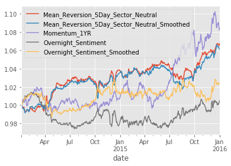

```python
ls_factor_returns = pd.DataFrame()

for factor, factor_data in clean_factor_data.items():
    ls_factor_returns[factor] = al.performance.factor_returns(factor_data).iloc[:, 0]

(1+ls_factor_returns).cumprod().plot()
```

### Basis Points Per Day per Quantile

It is not enough to look just at the factor weighted return. A good alpha is also monotonic in quantiles. Let's looks the basis points for the factor returns.

```
array([[<matplotlib.axes._subplots.AxesSubplot object at 0x7faed5c38780>,
      dtype=object)
```

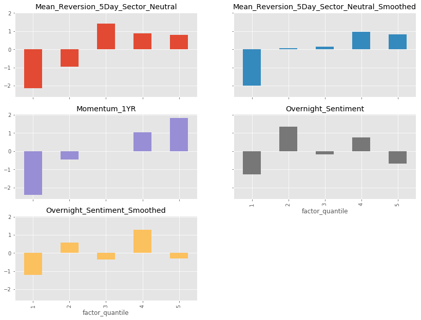

```python
qr_factor_returns = pd.DataFrame()

for factor, factor_data in unixt_factor_data.items():
    qr_factor_returns[factor] = al.performance.mean_return_by_quantile(factor_data)[0].iloc[:, 0]

(10000*qr_factor_returns).plot.bar(
    subplots=True,
    sharey=True,
    layout=(4,2),
    figsize=(14, 14),
    legend=False)
```

What do you observe?

## Turnover Analysis

Without doing a full and formal backtest, we can analyze how stable the alphas are over time. Stability in this sense means that from period to period, the alpha ranks do not change much. Since trading is costly, we always prefer, all other things being equal, that the ranks do not change significantly per period. We can measure this with the **factor rank autocorrelation (FRA)**.

alphalens.performance.factor_rank_autocorrelation

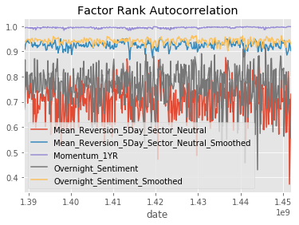

```python
ls_FRA = pd.DataFrame()

for factor, factor_data in unixt_factor_data.items():
    ls_FRA[factor] = al.performance.factor_rank_autocorrelation(factor_data)

ls_FRA.plot(title="Factor Rank Autocorrelation")
```

## Sharpe Ratio of the Alphas

The last analysis we'll do on the factors will be sharpe ratio. Implement `sharpe_ratio` to calculate the sharpe ratio of factor returns.

```python
def sharpe_ratio(factor_returns, annualization_factor):
    """
    Get the sharpe ratio for each factor for the entire period

    Parameters
    ----------
    factor_returns : DataFrame
        Factor returns for each factor and date
    annualization_factor: float
        Annualization Factor

    Returns
    -------
    sharpe_ratio : Pandas Series of floats
        Sharpe ratio
    """

    #TODO: Implement function
    sharpe_ratio = factor_returns.mean()/factor_returns.std()*annualization_factor

    return sharpe_ratio


project_tests.test_sharpe_ratio(sharpe_ratio)
```

```
Tests Passed
```

### View Data

Let's see what the sharpe ratio for the factors are. Generally, a Sharpe Ratio of near 1.0 or higher is an acceptable single alpha for this universe.

```python
daily_annualization_factor = np.sqrt(252)
sharpe_ratio(ls_factor_returns, daily_annualization_factor).round(2)
```

```
Mean_Reversion_5Day_Sector_Neutral            1.37000000
Mean_Reversion_5Day_Sector_Neutral_Smoothed   1.27000000
Momentum_1YR                                  1.13000000
Overnight_Sentiment                           0.12000000
Overnight_Sentiment_Smoothed                  0.45000000
dtype: float64
```

## Question: What do you think would happen if we smooth the momentum factor? Would the performance increase, decrease, or no major change? Why?

*#TODO: Put Answer In this Cell*

**Answer:**

- If we smooth the momentum factor there won't be major changes because momentum factor already has the largest autocorrelation.

## The Combined Alpha Vector

To use these alphas in a portfolio, we need to combine them somehow so we get a single score per stock. This is a area where machine learning can be very helpful. In this module, however, we will take the simplest approach of combination: simply averaging the scores from each alpha.

```python
selected_factors = all_factors.columns[[1, 2, 4]]
print('Selected Factors: {}'.format(', '.join(selected_factors)))

all_factors['alpha_vector'] = all_factors[selected_factors].mean(axis=1)
alphas = all_factors[['alpha_vector']]
alpha_vector = alphas.loc[all_factors.index.get_level_values(0)[-1]]
alpha_vector.head()
```

```
Selected Factors: Mean_Reversion_5Day_Sector_Neutral_Smoothed, Momentum_1YR, Overnight_Sentiment_Smoothed
```

| asset | alpha_vector |
| --- | --- |
| Equity(0 [A]) | -0.58642457 |
| Equity(1 [AAL]) | -0.45333845 |
| Equity(2 [AAP]) | -0.69993898 |
| Equity(3 [AAPL]) | -0.06790952 |
| Equity(4 [ABBV]) | -1.21617871 |

# Optimal Portfolio Constrained by Risk Model

You have an alpha model and a risk model. Let's find a portfolio that trades as close as possible to the alpha model but limiting risk as measured by the risk model. You'll be building thie optimizer for this portfolio. To help you out. we have provided you with an abstract class called `AbstractOptimalHoldings`.

```python
from abc import ABC, abstractmethod


class AbstractOptimalHoldings(ABC):
    @abstractmethod
    def _get_obj(self, weights, alpha_vector):
        """
        Get the objective function

        Parameters
        ----------
        weights : CVXPY Variable
            Portfolio weights
        alpha_vector : DataFrame
            Alpha vector

        Returns
        -------
        objective : CVXPY Objective
            Objective function
        """

        raise NotImplementedError()

    @abstractmethod
    def _get_constraints(self, weights, factor_betas, risk):
        """
        Get the constraints

        Parameters
        ----------
        weights : CVXPY Variable
            Portfolio weights
        factor_betas : 2 dimensional Ndarray
            Factor betas
        risk: CVXPY Atom
            Predicted variance of the portfolio returns

        Returns
        -------
        constraints : List of CVXPY Constraint
            Constraints
        """

        raise NotImplementedError()

    def _get_risk(self, weights, factor_betas, alpha_vector_index, factor_cov_matrix, idiosyncratic_var_vector):
        f = factor_betas.loc[alpha_vector_index].values.T * weights
        X = factor_cov_matrix
        S = np.diag(idiosyncratic_var_vector.loc[alpha_vector_index].values.flatten())

        return cvx.quad_form(f, X) + cvx.quad_form(weights, S)

    def find(self, alpha_vector, factor_betas, factor_cov_matrix, idiosyncratic_var_vector):
        weights = cvx.Variable(len(alpha_vector))
        risk = self._get_risk(weights, factor_betas, alpha_vector.index, factor_cov_matrix, idiosyncratic_var_vector)

        obj = self._get_obj(weights, alpha_vector)
        constraints = self._get_constraints(weights, factor_betas.loc[alpha_vector.index].values, risk)

        prob = cvx.Problem(obj, constraints)
        prob.solve(max_iters=500)

        optimal_weights = np.asarray(weights.value).flatten()

        return pd.DataFrame(data=optimal_weights, index=alpha_vector.index)
```

## Objective and Constraints

Using this class as a base class, you'll implement the `OptimalHoldings` class. There's two functions that need to be implemented in this class, the `_get_obj` and `_get_constraints` functions.

The `_get_obj` function should return an CVXPY objective function that maximizes $ \alpha^T * x \\ $, where $ x $ is the portfolio weights and $ \alpha $ is the alpha vector.

The `_get_constraints` function should return a list of the following constraints:

- $ r \leq risk_{\text{cap}}^2 \\ $
- $ B^T * x \preceq factor_{\text{max}} \\ $
- $ B^T * x \succeq factor_{\text{min}} \\ $
- $ x^T\mathbb{1} = 0 \\ $
- $ \|x\|_1 \leq 1 \\ $
- $ x \succeq weights_{\text{min}} \\ $
- $ x \preceq weights_{\text{max}} $

Where $ x $ is the portfolio weights, $ B $ is the factor betas, and $ r $ is the portfolio risk

The first constraint is that the predicted risk be less than some maximum limit. The second and third constraints are on the maximum and minimum portfolio factor exposures. The fourth constraint is the "market neutral constraint: the sum of the weights must be zero. The fifth constraint is the leverage constraint: the sum of the absolute value of the weights must be less than or equal to 1.0. The last are some minimum and maximum limits on individual holdings.

```python
class OptimalHoldings(AbstractOptimalHoldings):
    def _get_obj(self, weights, alpha_vector):
        """
        Get the objective function

        Parameters
        ----------
        weights : CVXPY Variable
            Portfolio weights
        alpha_vector : DataFrame
            Alpha vector

        Returns
        -------
        objective : CVXPY Objective
            Objective function
        """
        assert(len(alpha_vector.columns) == 1)

        #TODO: Implement function
        objective = cvx.Maximize(alpha_vector.T.values*weights)

        return objective

    def _get_constraints(self, weights, factor_betas, risk):
        """
        Get the constraints

        Parameters
        ----------
        weights : CVXPY Variable
            Portfolio weights
        factor_betas : 2 dimensional Ndarray
            Factor betas
        risk: CVXPY Atom
            Predicted variance of the portfolio returns

        Returns
        -------
        constraints : List of CVXPY Constraint
            Constraints
        """
        assert(len(factor_betas.shape) == 2)

        #TODO: Implement function
        constraints = [
            risk <= self.risk_cap**2,
            factor_betas.T*weights <= self.factor_max,
            factor_betas.T*weights >= self.factor_min,
            sum(weights) == 0.0,
            sum(cvx.abs(weights)) <= 1.0,
            weights >= self.weights_min,
            weights <= self.weights_max
        ]

        return constraints

    def __init__(self, risk_cap=0.05, factor_max=10.0, factor_min=-10.0, weights_max=0.55, weights_min=-0.55):
        self.risk_cap=risk_cap
        self.factor_max=factor_max
        self.factor_min=factor_min
        self.weights_max=weights_max
        self.weights_min=weights_min


project_tests.test_optimal_holdings_get_obj(OptimalHoldings)
project_tests.test_optimal_holdings_get_constraints(OptimalHoldings)
```

```
Running Integration Test on Problem.solve:
> constaints = [sum(weights) == 0.0, sum(cvx.abs(weights)) <= 1.0]
> obj = optimal_holdings._get_obj(weights, alpha_vector)
> prob = cvx.Problem(obj, constaints)
> prob.solve(max_iters=500)
> solution = np.asarray(weights.value).flatten()

Tests Passed

Running Integration Test on Problem.solve:
> x = np.diag(np.arange(3))
> s = np.diag(np.arange(4))
> factor_betas = np.arange(4 * 3).reshape([4, 3])
> risk = cvx.quad_form(weights * factor_betas, x) + cvx.quad_form(weights, s)
> constaints = optimal_holdings._get_constraints(weights, factor_betas, risk)
> obj = cvx.Maximize([0, 1, 5, -1] * weights)
> prob = cvx.Problem(obj, constaints)
> prob.solve(max_iters=500)
> solution = np.asarray(weights.value).flatten()

Tests Passed
```

[output not shown]

### View Data

With the `OptimalHoldings` class implemented, let's see the weights it generates.

[output not shown]

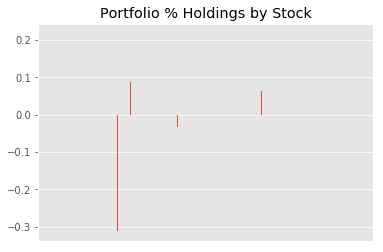

```python
optimal_weights = OptimalHoldings().find(alpha_vector, risk_model['factor_betas'], risk_model['factor_cov_matrix'], risk_model['idiosyncratic_var_vector'])

optimal_weights.plot.bar(legend=None, title='Portfolio % Holdings by Stock')
x_axis = plt.axes().get_xaxis()
x_axis.set_visible(False)
```

Yikes. It put most of the weight in a few stocks.

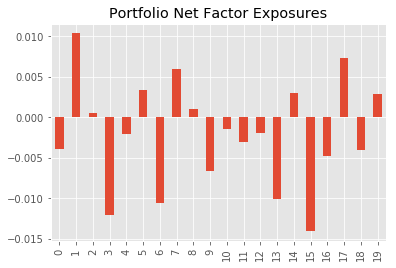

```python
project_helper.get_factor_exposures(risk_model['factor_betas'], optimal_weights).plot.bar(
    title='Portfolio Net Factor Exposures',
    legend=False)
```

## Optimize with a Regularization Parameter

**Note:** *$ \lambda $ is located in `self.lambda_reg`.*

```python
class OptimalHoldingsRegualization(OptimalHoldings):
    def _get_obj(self, weights, alpha_vector):
        """
        Get the objective function

        Parameters
        ----------
        weights : CVXPY Variable
            Portfolio weights
        alpha_vector : DataFrame
            Alpha vector

        Returns
        -------
        objective : CVXPY Objective
            Objective function
        """
        assert(len(alpha_vector.columns) == 1)

        #TODO: Implement function
        objective = cvx.Maximize((alpha_vector.T.values*weights) - (self.lambda_reg*cvx.norm(weights, 2)))

        return objective

    def __init__(self, lambda_reg=0.5, risk_cap=0.05, factor_max=10.0, factor_min=-10.0, weights_max=0.55, weights_min=-0.55):
        self.lambda_reg = lambda_reg
        self.risk_cap=risk_cap
        self.factor_max=factor_max
        self.factor_min=factor_min
        self.weights_max=weights_max
        self.weights_min=weights_min


project_tests.test_optimal_holdings_regualization_get_obj(OptimalHoldingsRegualization)
```

```
Running Integration Test on Problem.solve:
> constaints = [sum(weights) == 0.0, sum(cvx.abs(weights)) <= 1.0]
> obj = optimal_holdings_regualization._get_obj(weights, alpha_vector)
> prob = cvx.Problem(obj, constaints)
> prob.solve(max_iters=500)
> solution = np.asarray(weights.value).flatten()

Tests Passed
```

### View Data

[output not shown]

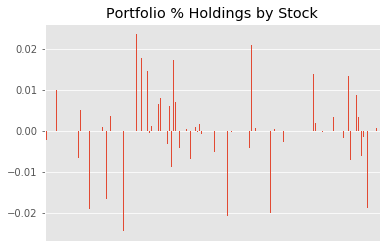

```python
optimal_weights_1 = OptimalHoldingsRegualization(lambda_reg=5.0).find(alpha_vector, risk_model['factor_betas'], risk_model['factor_cov_matrix'], risk_model['idiosyncratic_var_vector'])

optimal_weights_1.plot.bar(legend=None, title='Portfolio % Holdings by Stock')
x_axis = plt.axes().get_xaxis()
x_axis.set_visible(False)
```

Nice. Well diversified.

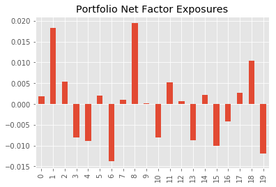

```python
project_helper.get_factor_exposures(risk_model['factor_betas'], optimal_weights_1).plot.bar(
    title='Portfolio Net Factor Exposures',
    legend=False)
```

## Optimize with a Strict Factor Constraints and Target Weighting

Another common formulation is to take a predefined target weighting, $x^*$ (e.g., a quantile portfolio), and solve to get as close to that portfolio while respecting portfolio-level constraints. For this next class, `OptimalHoldingsStrictFactor`, you'll implement the `_get_obj` function to minimize on on $ \|x - x^*\|_2 $, where $ x $ is the portfolio weights $ x^* $ is the target weighting.

```python
class OptimalHoldingsStrictFactor(OptimalHoldings):
    def _get_obj(self, weights, alpha_vector):
        """
        Get the objective function

        Parameters
        ----------
        weights : CVXPY Variable
            Portfolio weights
        alpha_vector : DataFrame
            Alpha vector

        Returns
        -------
        objective : CVXPY Objective
            Objective function
        """
        assert(len(alpha_vector.columns) == 1)

        #TODO: Implement function
        alpha_vector_norm = ((alpha_vector.values - alpha_vector.values.mean()) / np.sum(np.abs(alpha_vector.values))).flatten()
        objective = cvx.Minimize(cvx.norm(weights - alpha_vector_norm))

        return objective


project_tests.test_optimal_holdings_strict_factor_get_obj(OptimalHoldingsStrictFactor)
```

```
Running Integration Test on Problem.solve:
> constaints = [sum(weights) == 0.0, sum(cvx.abs(weights)) <= 1.0]
> obj = optimal_holdings_strict_factor._get_obj(weights, alpha_vector)
> prob = cvx.Problem(obj, constaints)
> prob.solve(max_iters=500)
> solution = np.asarray(weights.value).flatten()

Tests Passed
```

### View Data

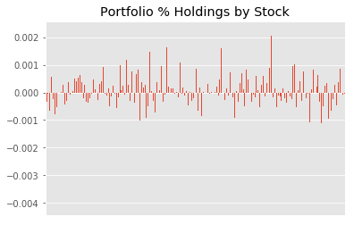

```python
optimal_weights_2 = OptimalHoldingsStrictFactor(
    weights_max=0.02,
    weights_min=-0.02,
    risk_cap=0.0015,
    factor_max=0.015,
    factor_min=-0.015).find(alpha_vector, risk_model['factor_betas'], risk_model['factor_cov_matrix'], risk_model['idiosyncratic_var_vector'])

optimal_weights_2.plot.bar(legend=None, title='Portfolio % Holdings by Stock')
x_axis = plt.axes().get_xaxis()
x_axis.set_visible(False)
```

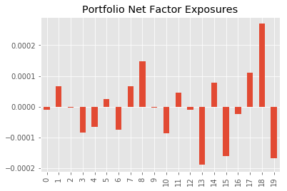

```python
project_helper.get_factor_exposures(risk_model['factor_betas'], optimal_weights_2).plot.bar(
    title='Portfolio Net Factor Exposures',
    legend=False)
```

## Submission

Now that you're done with the project, it's time to submit it. Click the submit button in the bottom right. One of our reviewers will give you feedback on your project with a pass or not passed grade. You can continue to the next section while you wait for feedback.